# Perry Meeting May 16 2022

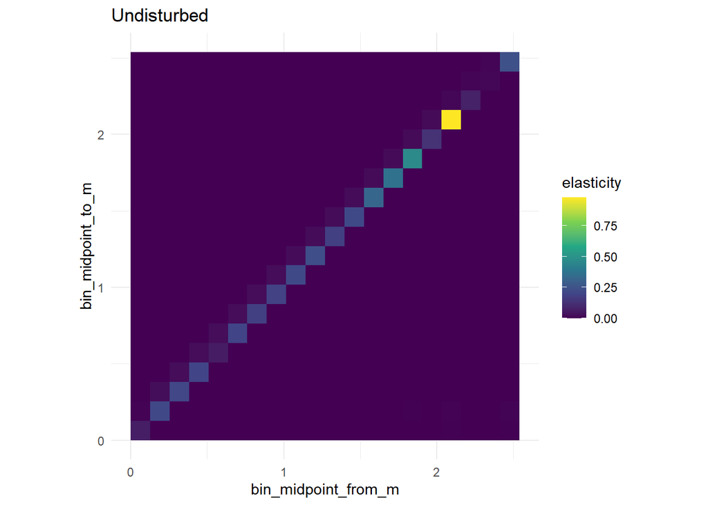

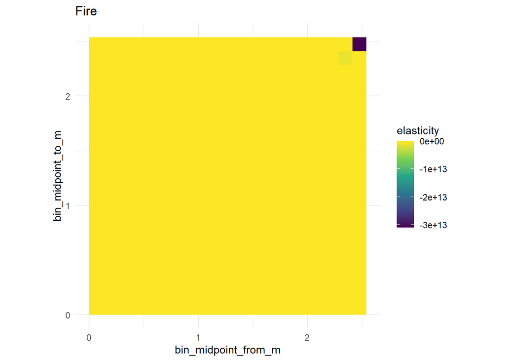

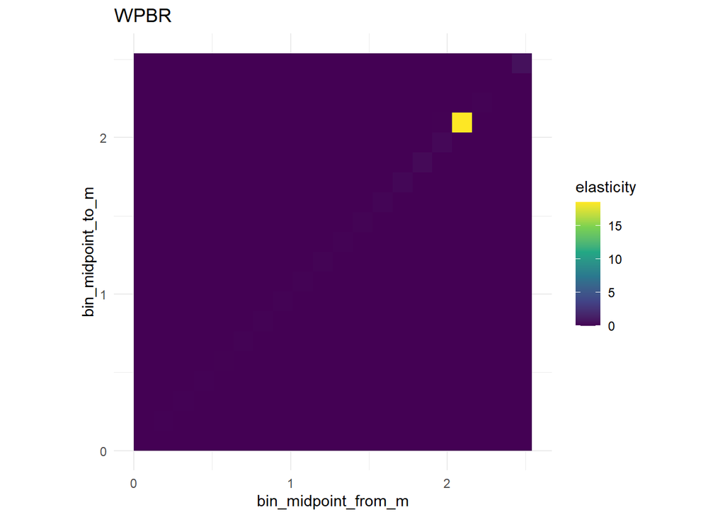

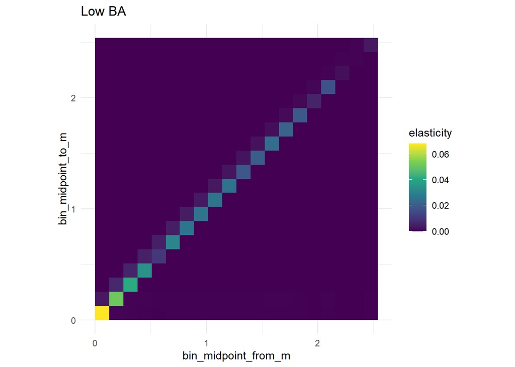

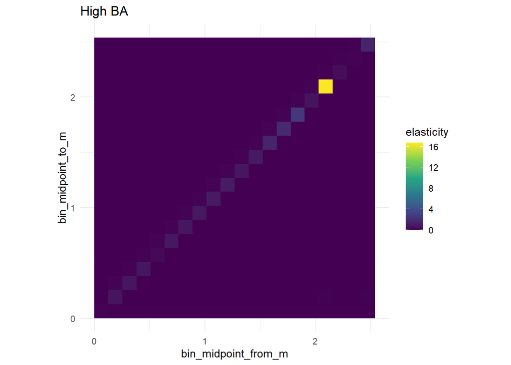

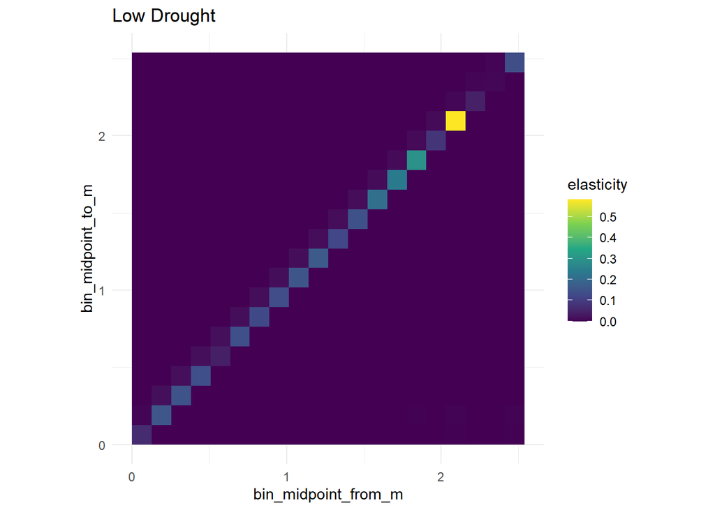

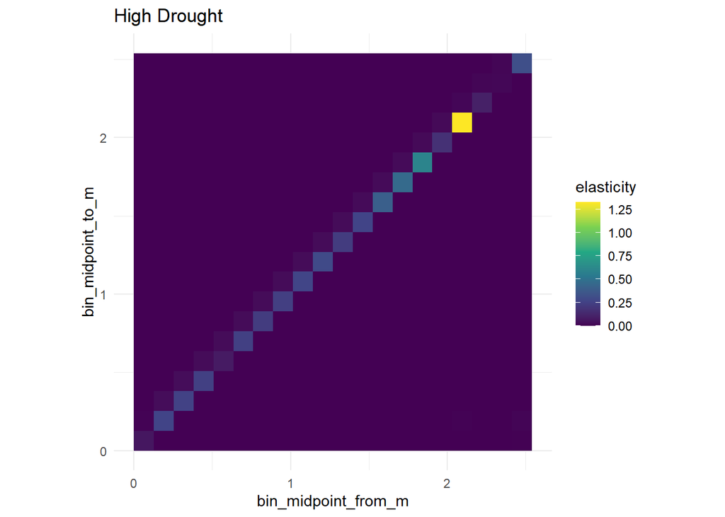

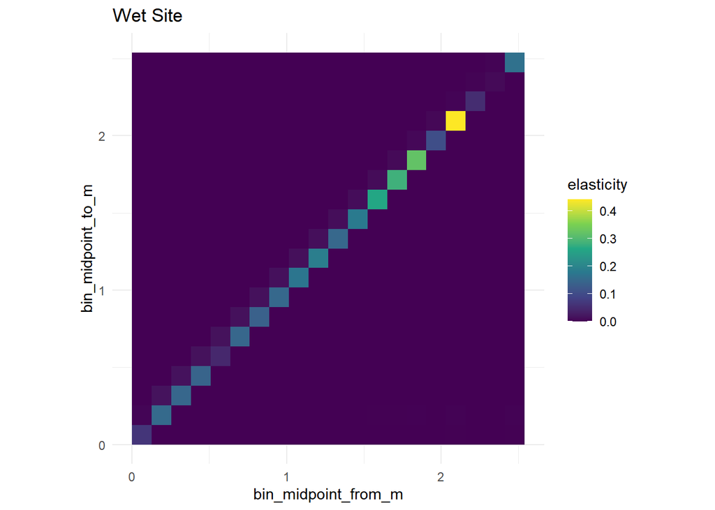

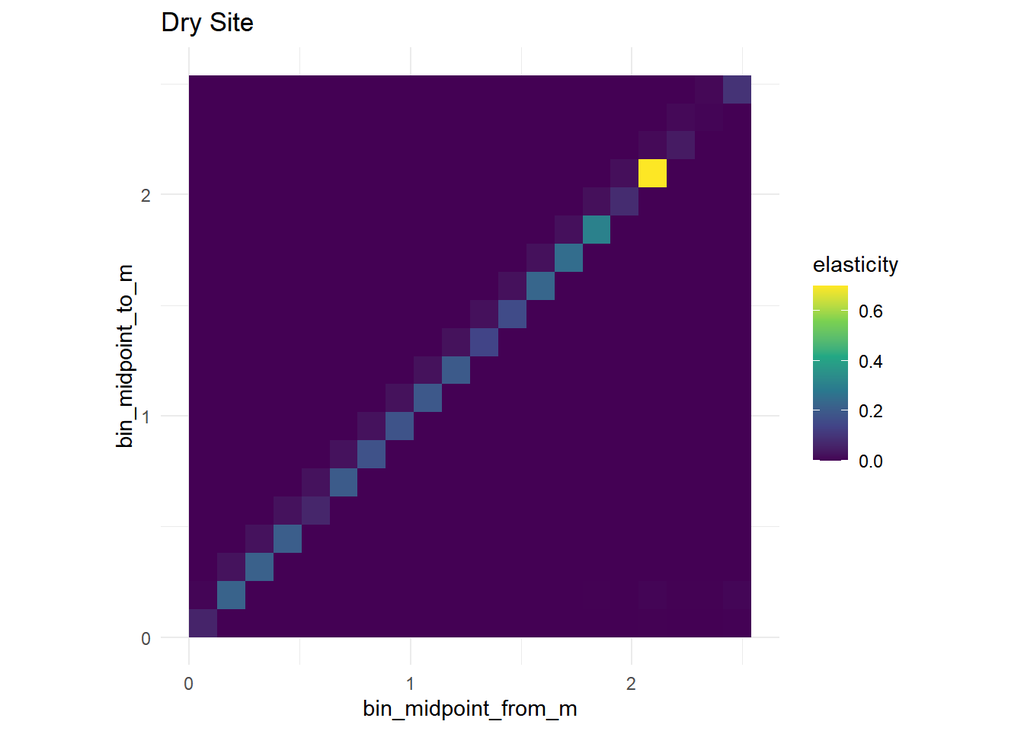

```r
elasticity_plots =
  lapply(X = 1:9,
         FUN = function(s){

              hypothetical_sens_elas_full.df %>%
              group_by(size_to, size_from, bin_midpoint_to_m, bin_midpoint_from_m,
                       subp_id) %>%
              summarise(sensitivity = median(sensitivity, na.rm = TRUE),
                        elasticity = median(elasticity, na.rm = TRUE)) %>%
              ungroup() %>%
              left_join(hypothetical_plots %>%
                          select(subp_id, name)) %>%
              filter(subp_id==s) %>%
              ggplot(aes(x = bin_midpoint_from_m,
                         y = bin_midpoint_to_m,
                         fill = elasticity))+
              geom_tile()+
              coord_fixed()+
              theme_minimal()+
              scale_fill_viridis_c()+
                labs(title = hypothetical_plots$name[s])
         })

elasticity_plots
```

The non-smoothness in the bin sizes is really apparent here. Also the fire one again looks bonkers.

Looking at the transition matrices, we get:

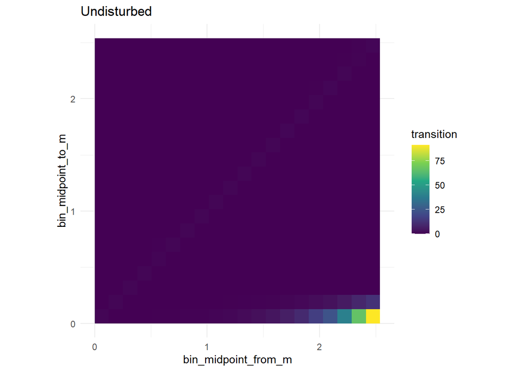

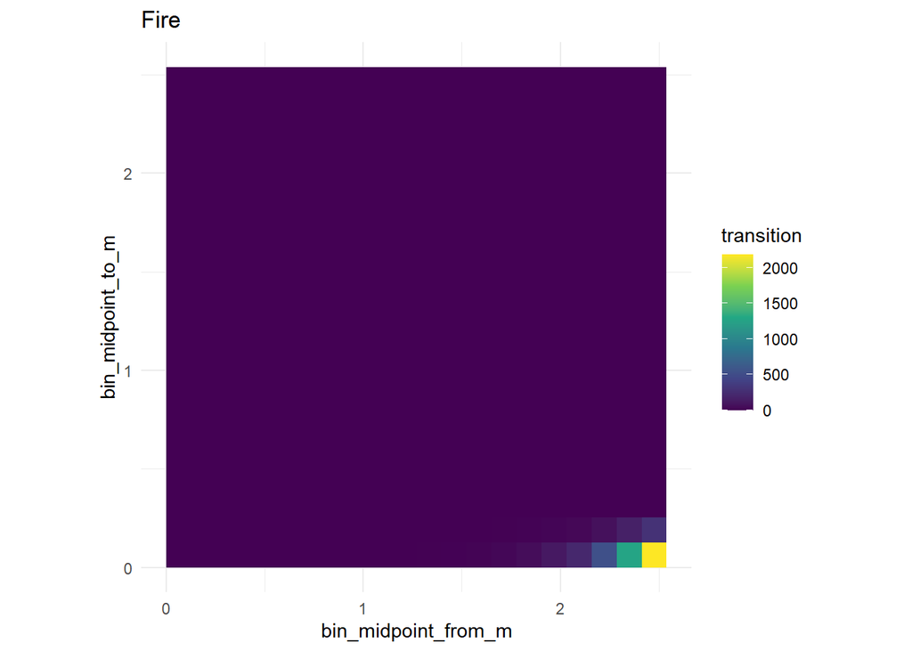

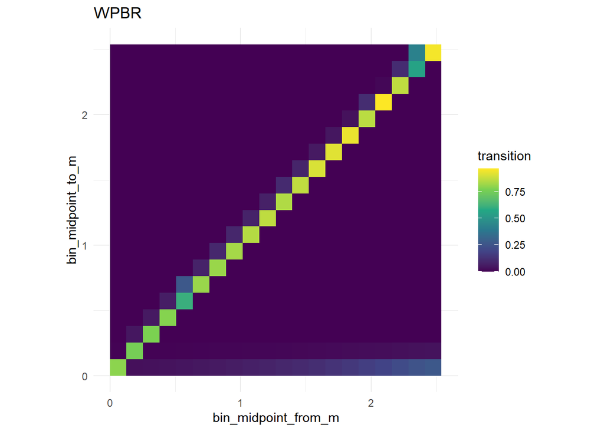

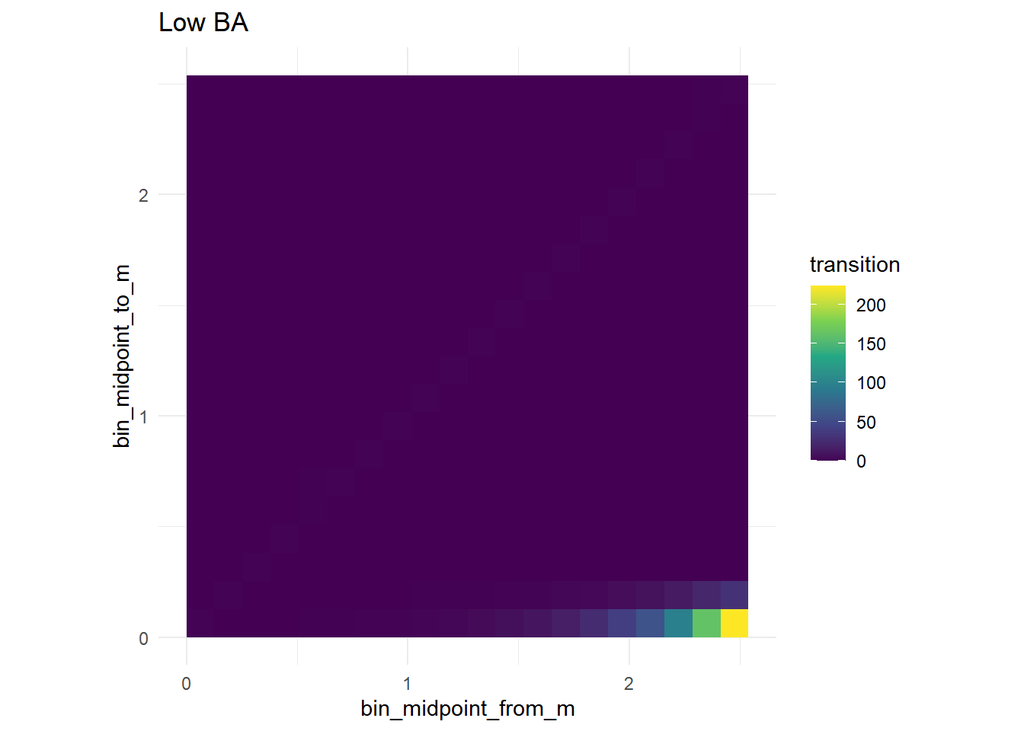

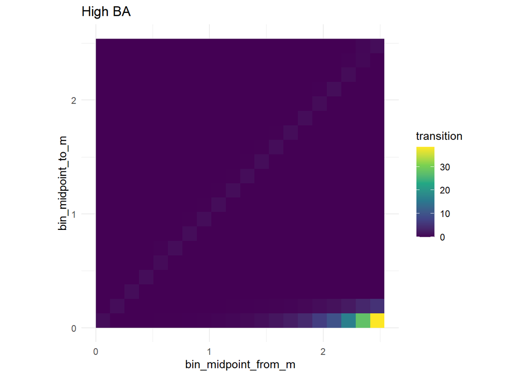

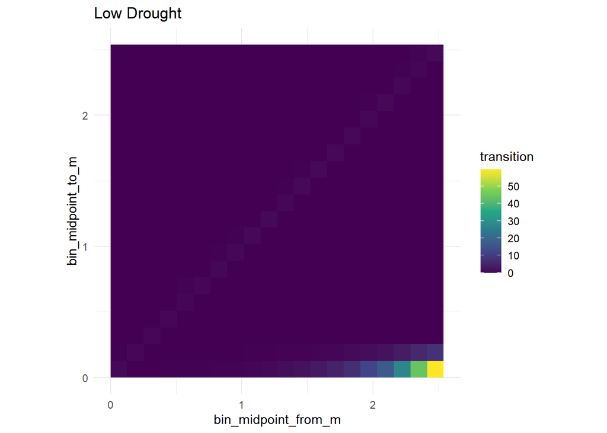

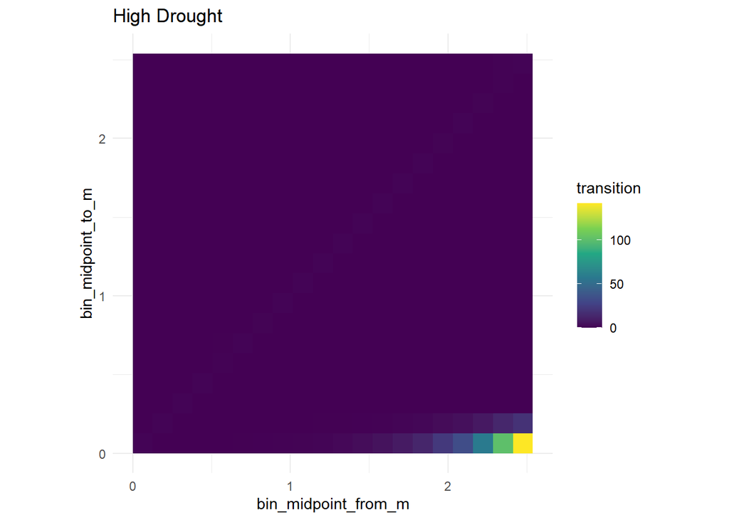

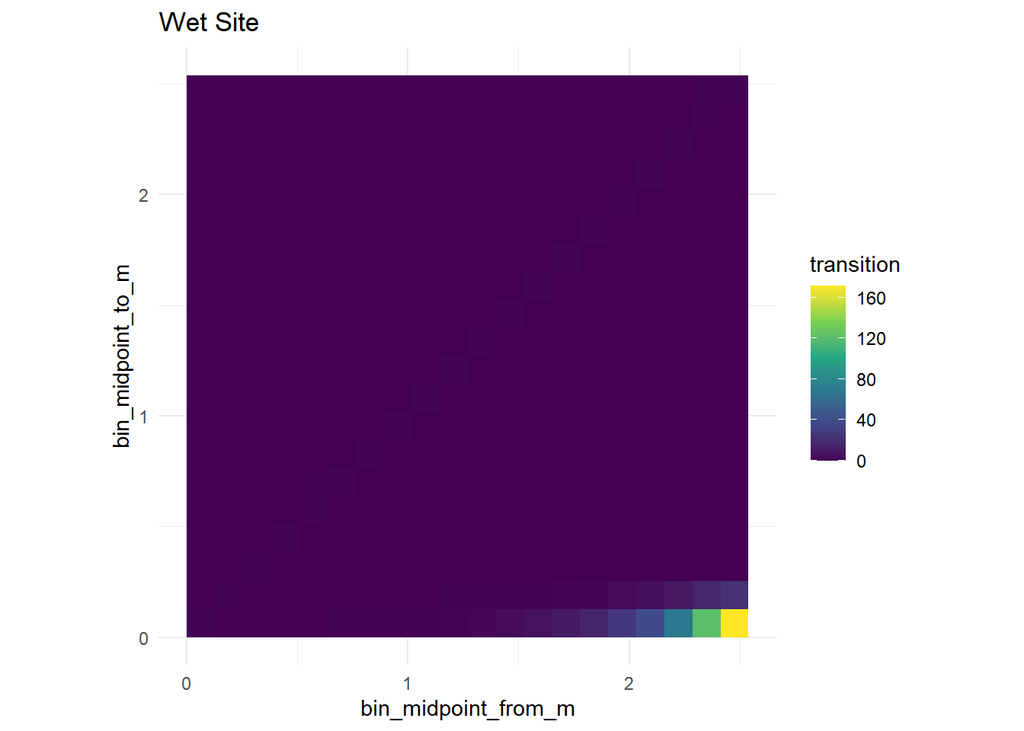

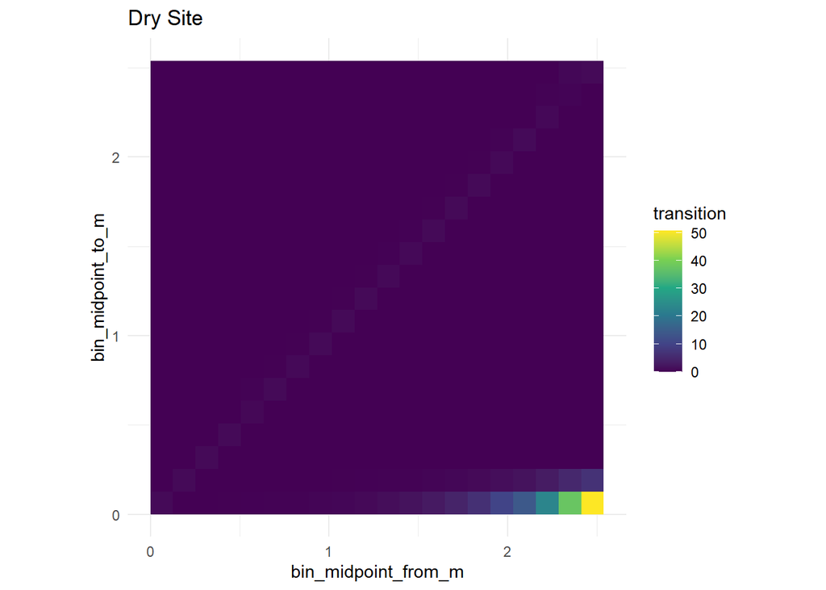

```r
hypothetical_sens_elas_full.df$transition =
    sapply(X = 1:nrow(hypothetical_plots),
         FUN = function(plot){
           sapply(X = 1:nrow(size_metadata),
                  FUN = function(size_to){

                    sapply(X = 1:nrow(size_metadata),
                           FUN = function(size_from){
                             A_hypotheticals_full[size_to, size_from, plot,]
                           })
                  })
         }) %>%
  as.vector()

transition_plots =
  lapply(X = 1:9,
         FUN = function(s){

              hypothetical_sens_elas_full.df %>%
              group_by(size_to, size_from, bin_midpoint_to_m, bin_midpoint_from_m,
                       subp_id) %>%
              summarise(sensitivity = median(sensitivity, na.rm = TRUE),
                        elasticity = median(elasticity, na.rm = TRUE),
                        transition = median(transition, na.rm = TRUE)) %>%
              ungroup() %>%
              left_join(hypothetical_plots %>%
                          select(subp_id, name)) %>%
              filter(subp_id==s) %>%
              ggplot(aes(x = bin_midpoint_from_m,
                         y = bin_midpoint_to_m,
                         fill = transition))+
              geom_tile()+
              coord_fixed()+
              theme_minimal()+
              scale_fill_viridis_c()+
                labs(title = hypothetical_plots$name[s])
         })

transition_plots
```

The transition kernels all look reasonable, with the main transitions being the super high recruitment numbers from the largest size classes. Note that the recruitment numbers are highest for the fire kernels, which was the model where there was a mildly positive interaction between fire and individual size for fecundity:

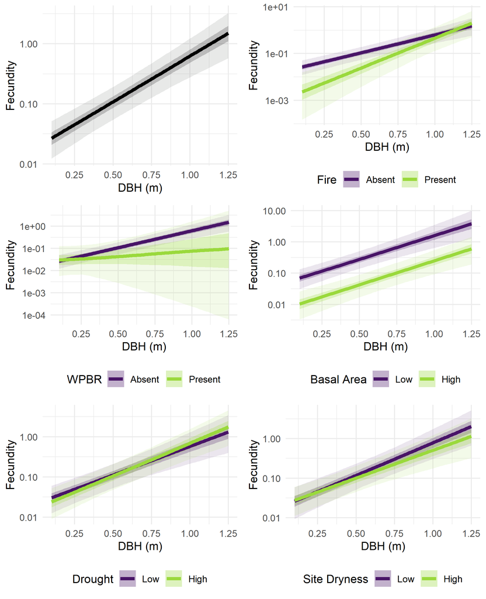

Fecundity fixed effects

# Problem is the large size classes?

Looking at all of this, I start to become skeptical of the IPM behavior for those biggest size classes. IMO it’s unlikely that the exponential relationship between individual size and fecundity continues from DBH of 1.25m to DBH of 2.5m, it probably levels off somewhere for the largest individuals. And I’m thinking that there is some sort of overflow thing happening with those really high transition values from the largest classes into the smallest ones, which is causing all the wonky results in the other summary statistics.

With all that in mind, I reran all of these analyses using a size distribution that only goes from 0-1.25m, which is about the 95th percentile individual size in the data, but ditches fully half of the size classes. I’m more confident in the vital rate predictions for this range of sizes, and it might help with numerical problems to avoid those super high recruitment rates?

# Real plots, limited size range

## Build transition matrices

```r
size_metadata_small =
  readRDS(here::here('02-data',
                     '01-preprocessed',
                     'size_metadata.rds')) %>%
  # convert to metric
  mutate(bin_midpoint = bin_midpoint * 0.0254,
         bin_lower = bin_lower * 0.0254,
         bin_upper = bin_upper * 0.0254,
         dbh_m.mean = dbh_in.mean * 0.0254) %>%

  # for testing, restrict to ~95th percentile observed size class
  filter(dbh_m.mean < 1.25)
# I've played around with only using "smaller"
# sizes in the IPM transition kernel, because I don't really believe some
# of the transition rates for very large trees (>1.25m dbh), because I doubt
# that the relationship between size and fecundity really keeps increasing
# exponentially that far into the tail of DBH. The
# parameter-medians-all-plots results are not sensitive to the range of
# sizes modeled in the transition matrix. The
# posterior-params-hypothetical-plots are slightly sensitive, in that the
# posterior lambda distributions for the different scenarios do shift (in
# particular, the posterior lambda distribution for burned plots shifts
# downward slightly), but the core findings (strong negative effect of fire
# reducing lambda below 1, weaker negative effects of WPBR and high BA reducing
# lambda to ~1, high positive effect of low BA, weak effects of drought and
# dryness) remain unchanged. For simplicity and clarity when writing a paper,
# i'd like the post-estimation IPM to have the same structure as the IPM used
# to estimate fecundity, and the results are not sensitive to the decision
# about what sizes to include in the IPM, so I'm leaving in the large size bins
# for the final publication analysis.

size_metadata_small$r =
  c(readRDS(here::here('02-data',
                       '02-for_analysis',
                       'pila_training.rds'))$r,
    rep(0, times = 8))
```

```r
A_median_half =
    array(dim = list(nrow(size_metadata_small),
                     nrow(size_metadata_small),
                     nrow(plots.pila)),
          dimnames = list('class_to' = 1:nrow(size_metadata_small),
                          'class_from' = 1:nrow(size_metadata_small),
                          'plot' = 1:nrow(plots.pila)),
          data =
            sapply(X = 1:nrow(plots.pila),
                   FUN = function(plot){

                     # construct explanatory variable matrix for vital rate
                     # functions for the current plot
                     X =
                       plots.pila %>%
                       slice(plot) %>%
                       expand(nesting(intercept, fire, wpbr, ba_scaled,
                                      cwd_dep90_scaled,cwd_mean_scaled),
                              dbh = size_metadata_small$dbh_m.mean) %>%
                       mutate(dbh_fire = dbh*fire,
                              dbh_wpbr = dbh*wpbr,
                              dbh_ba = dbh*ba_scaled,
                              dbh_cwd_dep90 = dbh*cwd_dep90_scaled,
                              dbh_cwd_mean = dbh*cwd_mean_scaled) %>%
                       select(intercept, dbh, fire, wpbr, ba_scaled,
                              cwd_dep90_scaled, cwd_mean_scaled,
                              dbh_fire, dbh_wpbr, dbh_ba,
                              dbh_cwd_dep90, dbh_cwd_mean) %>%
                       as.matrix()

                     # calculate vector of survival probabilities for each
                     # size class on this plot with this parameter draw
                     p =
                       boot::inv.logit(as.numeric(X %*% beta_s) +
                                         ecoEffect_s[plots.pila$ecosub.i[plot]]+
                                         plotEffect_s[plots.pila$plot_id.i][plot])

                     # calculate vector of mean size at time 2 for each size
                     # class on this plot with this parameter draw
                     mu = as.numeric(X %*% beta_g)+
                       ecoEffect_g[plots.pila$ecosub.i[plot]]+
                       plotEffect_g[plots.pila$plot_id.i[plot]]

                     # calculate vector of fecundity for each size class on this
                     # plot with this parameter draw
                     f =
                       exp(as.numeric(X %*% beta_f)+
                             ecoEffect_f[plots.pila$ecosub.i[plot]]+
                             plotEffect_f[plots.pila$plot_id.i[plot]])

                     # loop over each "from" size class
                     sapply(X = 1:nrow(size_metadata_small),
                            FUN = function(class_from){

                              # growth kernel from this size class into
                              # each other size class, using the cumulative
                              # density function as recommended by Doak et al. 2021
                              g =
                                ((pnorm(size_metadata_small$bin_upper,
                                        mu[class_from],
                                        sigmaEpsilon_g) -
                                    pnorm(size_metadata_small$bin_lower,
                                          mu[class_from],
                                          sigmaEpsilon_g))/
                                   (1-pnorm(0,
                                            mu[class_from],
                                            sigmaEpsilon_g)))

                              # loop over every destination size class
                              sapply(X = 1:nrow(size_metadata_small),
                                     FUN = function(class_to){

                                       # for testing, just to make sure
                                       # I've constructed the array correctly
                                       #paste0('to:',class_to,',from:',class_from,
                                       #       ',plot:',plot)

                                       # calculate the transition kernel
                                       # between the current "from" class and
                                       # the current "to" class
                                       transition_kern =
                                         # survival of each from class
                                         (p[class_from] *
                                            # prob of growth from to
                                            g[class_to]) +
                                         # number of new recruits in this "to"
                                         # class is the fecundity of the "from"
                                         # class times the recruitment size
                                         # kernel for this "to" class
                                         (f[class_from] *
                                            size_metadata_small$r[class_to])
                                       return(transition_kern)

                                     })

                            })

                   }))

# save this so we don't have to rebuild it every time we knit
saveRDS(A_median_half,
        here::here('02-data',
                   '03-results',
                   'real_fits',
                   'A_median_half.rds'))
```

```r
A_median_half = readRDS(here::here('02-data',
                                   '03-results',
                                   'real_fits',
                                   'A_median_half.rds'))
```

Here’s the median transition matrix across all the plots:

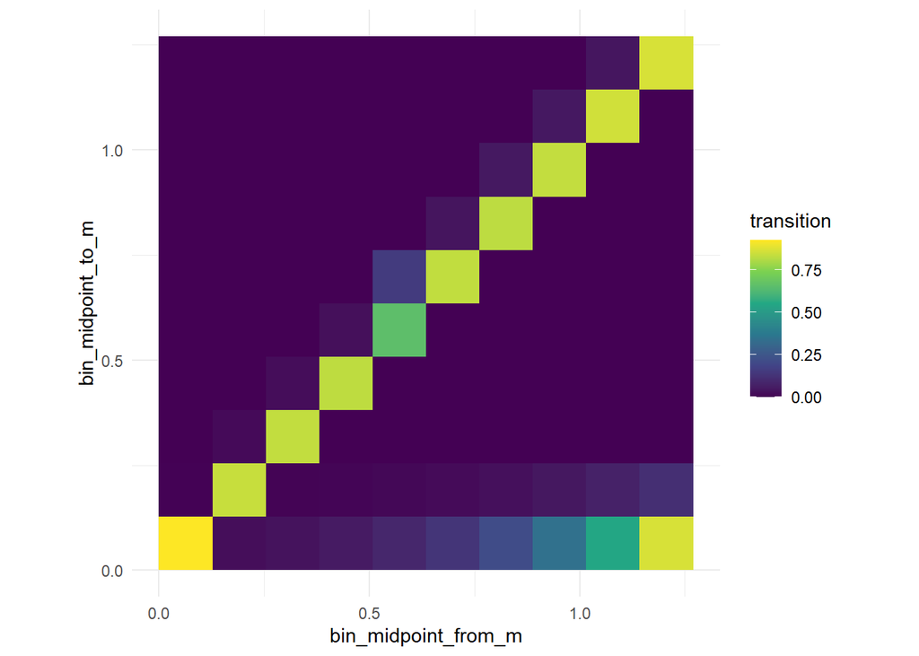

```r
sens_elas_plot_half.df =
  expand.grid(size_to = size_metadata_small$bin_id,
              size_from = size_metadata_small$bin_id) %>%
  left_join(size_metadata_small %>%
              select(size_to = bin_id,
                     bin_midpoint_to_m = bin_midpoint)) %>%
  left_join(size_metadata_small %>%
              select(size_from = bin_id,
                     bin_midpoint_from_m = bin_midpoint)) %>%
  expand(nesting(size_to, size_from, bin_midpoint_to_m, bin_midpoint_from_m),
         plot = 1:nrow(plots.pila)) %>%

  arrange(plot, size_to, size_from)

sens_elas_plot_half.df$transition =

  sapply(X = 1:nrow(plots.pila),
         FUN = function(plot){

           sapply(X = 1:nrow(size_metadata_small),
                  FUN = function(size_to){

                    sapply(X = 1:nrow(size_metadata_small),
                           FUN = function(size_from){

                             A_median_half[size_to, size_from, plot]

                           })

                  })

         }) %>%
  as.vector()

sens_elas_plot_half.df %>%
  group_by(size_to, size_from, bin_midpoint_to_m, bin_midpoint_from_m) %>%
  summarise(transition = median(transition)) %>%
  ungroup() %>%
  ggplot(aes(x = bin_midpoint_from_m,
             y = bin_midpoint_to_m,
             fill = transition))+
  geom_tile()+
  coord_fixed()+
  theme_minimal()+
  scale_fill_viridis_c()
```

That weird transition seems to be because the mean DBH for that class is slightly above the midpoint, rather than slightly below as for all the other classes.

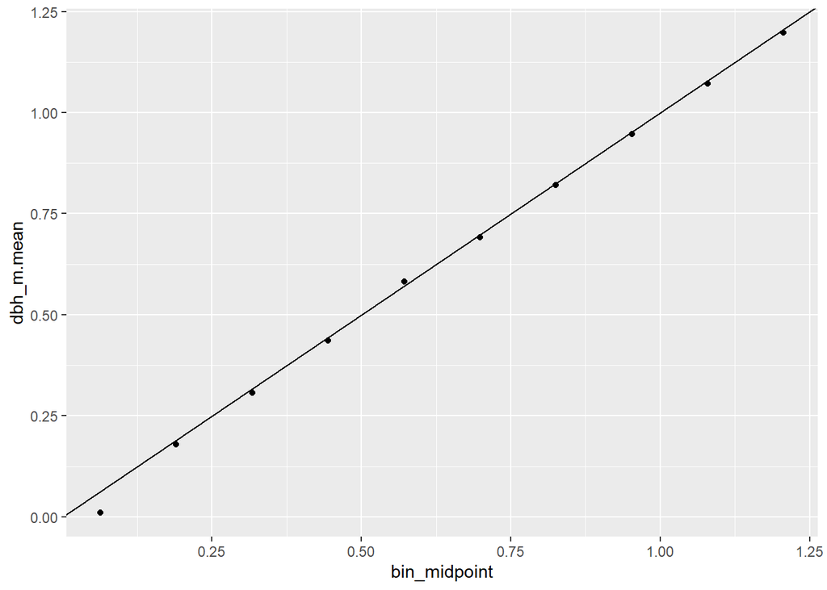

```r
ggplot(size_metadata_small, aes(x = bin_midpoint, y = dbh_m.mean))+
  geom_point()+
  geom_abline(intercept = 0, slope = 1)
```

The diagonal in this matrix is not strictly the survival, which is why the diagonal is highest for the smallest size classes, because in the other classes there are more individuals growing out of their current class and into a bigger one? That makes sense.

## Asymptotic population growth rate

```r
lambda_half =
  sapply(X = 1:nrow(plots.pila),
         FUN = function(plot){
           A_plot = A_median_half[,,plot]
           lambda_plot = max(as.numeric(Re(eigen(A_plot)$values)))
           return(lambda_plot)
         })
```

This is the equivalent to figure 7 in the paper, but with the size-restricted IPMs.

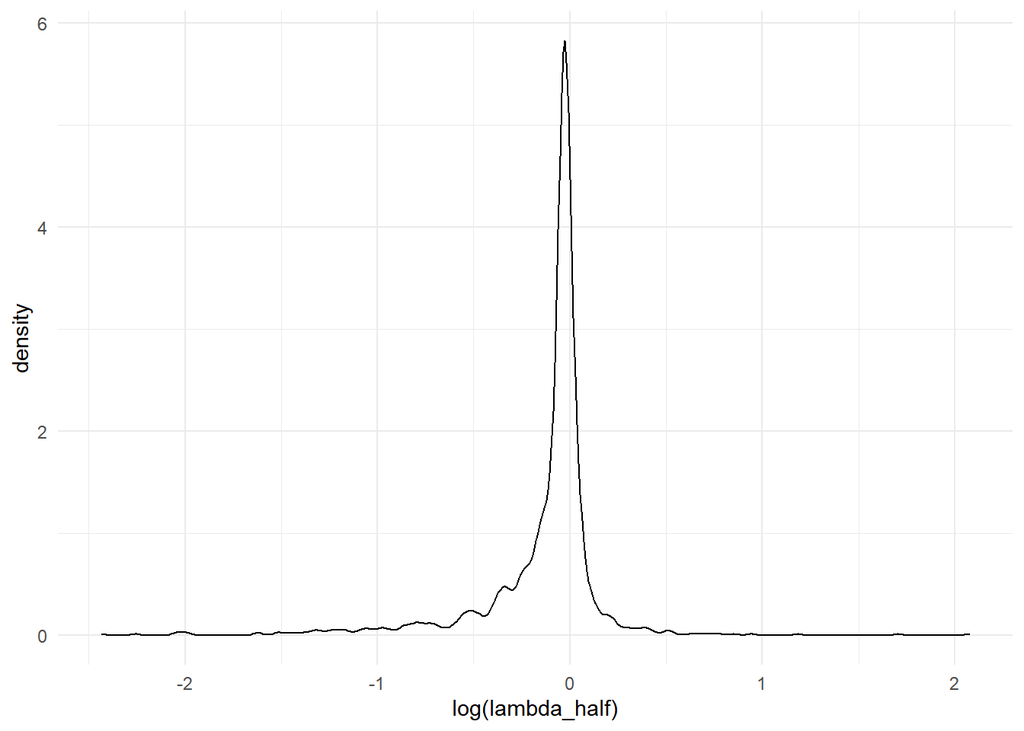

```r
ggplot(data.frame(lambda_half),
       aes(x = log(lambda_half)))+
  geom_density()+
  theme_minimal()
```

Results are similar, though here 78% of plots have a lambda below one rather than 64%.

```r
length(lambda_half[lambda_half < 1])/length(lambda_half)
```

```
## [1] 0.7867514
```

## Stable size distribution

```r
# stable size distribution
ssd_half =
  matrix(nrow = nrow(size_metadata_small),
         ncol = nrow(plots.pila),
         byrow = FALSE,
         data =
           sapply(X = 1:nrow(plots.pila),
                  FUN = function(plot){
                    A.plot = A_median_half[,,plot]
                    # from supplamentory materials for merow et al 2014
                    # "On using integral projection models..."
                    w.eigen = Re(eigen(A.plot)$vectors[,1])
                    ssd = w.eigen / sum(w.eigen)
                    return(ssd)
                  }))

ssd_half.df =
  expand.grid('plot' = 1:nrow(plots.pila),
              'sizeclass' = 1:nrow(size_metadata_small)) %>%
  left_join(size_metadata_small %>%
              mutate(bin_midpoint_cm = bin_midpoint*100) %>%
              select(sizeclass = bin_id, bin_midpoint_cm))

ssd_half.df$class_proportion =

  as.numeric(
    sapply(X = 1:nrow(size_metadata_small),
           FUN = function(sizeclass){

             return(ssd_half[sizeclass,])

           })
  )
```

Stable size distribution looks similar:

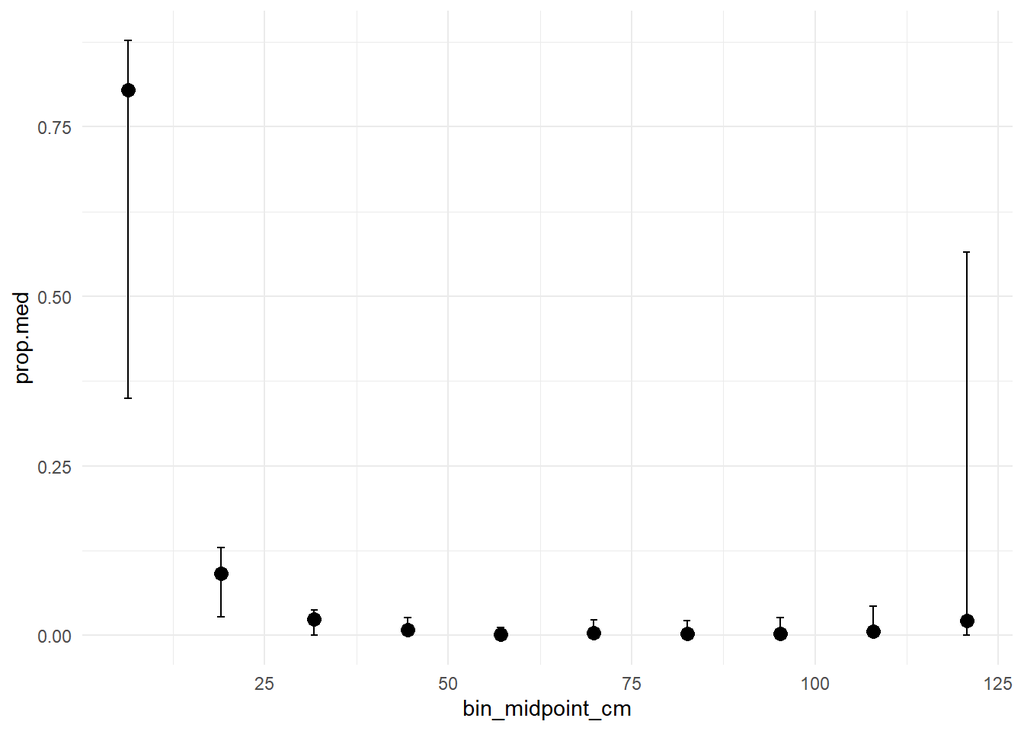

```r
# stable size distribution is inverse J not surprising
ssd_half.df %>%
  group_by(bin_midpoint_cm, sizeclass) %>%
  summarise(prop.med = median(class_proportion),
            prop.05 = quantile(class_proportion, 0.05),
            prop.95 = quantile(class_proportion, 0.95)) %>%
  ungroup() %>%
  ggplot(aes(x = bin_midpoint_cm))+
  geom_point(aes(y = prop.med), size = 3)+
  geom_errorbar(aes(ymin = prop.05, ymax = prop.95),
                width = 1)+
  theme_minimal()
```

This is a little weird, why are trees accumulating in the largest size class? Is this some eviction problem? I’m not doing anything special with that largest class but maybe I should be using a really high upper bound for the growth kernel CDF there?

Log scaled y axis for clarity:

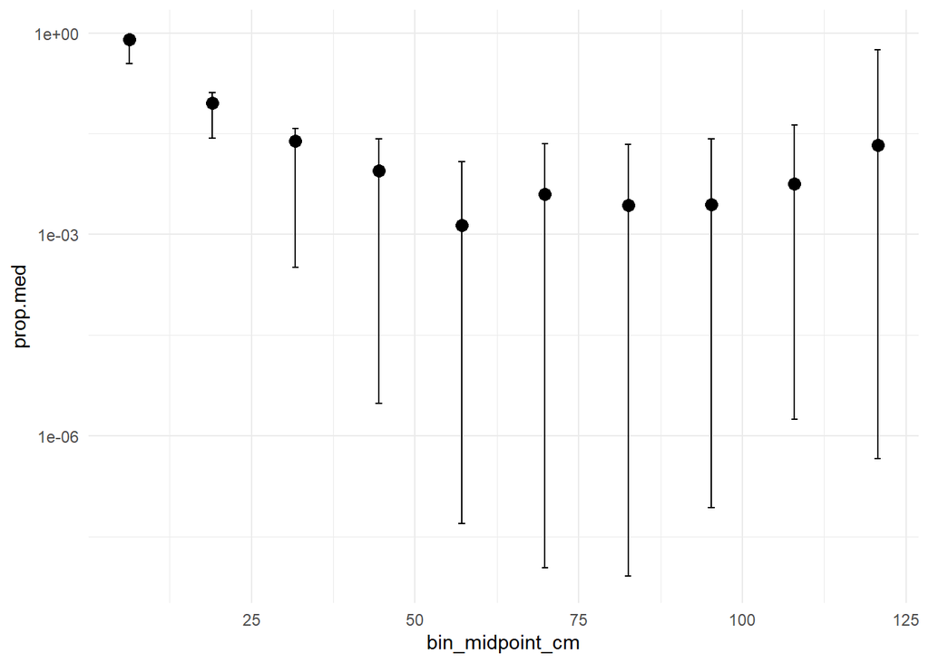

```r
# stable size distribution is inverse J not surprising
ssd_half.df %>%
  group_by(bin_midpoint_cm, sizeclass) %>%
  summarise(prop.med = median(class_proportion),
            prop.05 = quantile(class_proportion, 0.05),
            prop.95 = quantile(class_proportion, 0.95)) %>%
  ungroup() %>%
  ggplot(aes(x = bin_midpoint_cm))+
  geom_point(aes(y = prop.med), size = 3)+
  geom_errorbar(aes(ymin = prop.05, ymax = prop.95),
                width = 1)+
  theme_minimal()+
  scale_y_log10()
```

Again the largest classes start to get a little more common under the stable size distribution than the middling classes.

## Reproductive value

```r
plot_repro.half =
  matrix(nrow = nrow(size_metadata_small),
         ncol = nrow(plots.pila),
         byrow = FALSE,
         data =
           sapply(X = 1:nrow(plots.pila),
                  FUN = function(plot){
                    A.plot = A_median_half[,,plot]
                    # from supplementary materials for merow et al 2014
                    # "On using integral projection models..."
                    v.eigen = Re(eigen(t(A.plot))$vectors[,1])
                    rv = v.eigen / v.eigen[1]
                    return(rv)
                  }))


plot_repro_half.df =
  expand.grid('plot' = 1:nrow(plots.pila),
              'sizeclass' = 1:nrow(size_metadata_small)) %>%
  left_join(size_metadata_small %>%
              mutate(bin_midpoint_cm = bin_midpoint*100) %>%
              select(sizeclass = bin_id, bin_midpoint_cm))

plot_repro_half.df$reproductive_value =

  as.numeric(
    sapply(X = 1:nrow(size_metadata_small),
           FUN = function(sizeclass){

             return(plot_repro.half[sizeclass,])

           })
  )
```

Have some large negative values.

```r
plot_repro_half.df  %>% summary()
```

```
##       plot          sizeclass    bin_midpoint_cm  reproductive_value
##  Min.   :   1.0   Min.   : 1.0   Min.   :  6.35   Min.   :-2.406e+18
##  1st Qu.: 276.0   1st Qu.: 3.0   1st Qu.: 31.75   1st Qu.: 9.000e+00
##  Median : 551.5   Median : 5.5   Median : 63.50   Median : 5.100e+01
##  Mean   : 551.5   Mean   : 5.5   Mean   : 63.50   Mean   : 2.815e+14
##  3rd Qu.: 827.0   3rd Qu.: 8.0   3rd Qu.: 95.25   3rd Qu.: 1.417e+03
##  Max.   :1102.0   Max.   :10.0   Max.   :120.65   Max.   : 4.770e+18
```

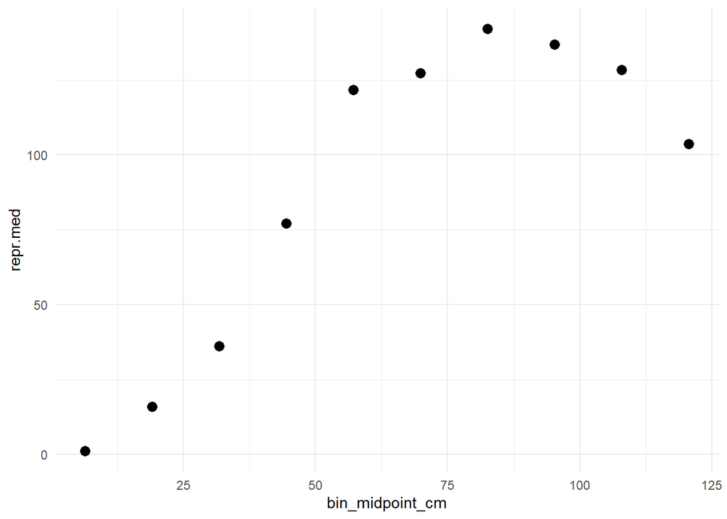

```r
plot_repro_half.df %>%

  group_by(bin_midpoint_cm, sizeclass) %>%

  # there's a couple of NA plots for reproductive value, looks like cases
  # where numerical errors are resulting in a divide by zero when going from
  # v.eigen to reproductive value?
  summarise(repr.med = median(reproductive_value, na.rm = TRUE),

            # there's a couple of NAs in h
            repr.05 = quantile(reproductive_value, 0.25, na.rm = TRUE),
            repr.95 = quantile(reproductive_value, 0.75, na.rm = TRUE)) %>%
  ungroup() %>%
  ggplot(aes(x = bin_midpoint_cm))+
  geom_point(aes(y = repr.med), size = 3)+
  #geom_errorbar(aes(ymin = repr.05, ymax = repr.95),
  #              width = 1)+
  theme_minimal()
```

Reproductive value is capping out or something? I don’t understand why its not monotinically increasing with size. And there’s **still** a bunch (228 / 11020) of plot:sizeclass combinations where we have a have a negative reproductive value, sometimes with large magnitude.

```r
nrow(plot_repro_half.df %>% filter(reproductive_value<0))
```

```
## [1] 228
```

## Sensitivity and elasticity

```r
# sensitivity and elasticity
v.dot.w_plot_half =

  sapply(X = 1:nrow(plots.pila),
         FUN = function(plot){
           sum(ssd_half[,plot] * plot_repro.half[,plot])*0.127
         })

sens_plot_half =
  array(dim = list(nrow(size_metadata_small),
                   nrow(size_metadata_small),
                   nrow(plots.pila)),
        dimnames =
          list('size_to' = 1:nrow(size_metadata_small),
               'size_from' = 1:nrow(size_metadata_small),
               'plot' = 1:nrow(plots.pila)),
        data =
          sapply(X = 1:nrow(plots.pila),
                 FUN = function(plot){
                   outer(plot_repro.half[,plot], ssd_half[,plot])/
                     v.dot.w_plot_half[plot]
                 }))


elas_plot_half =

  array(dim = list(nrow(size_metadata_small),
                   nrow(size_metadata_small),
                   nrow(plots.pila)),
        dimnames =
          list('size_to' = 1:nrow(size_metadata_small),
               'size_from' = 1:nrow(size_metadata_small),
               'plot' = 1:nrow(plots.pila)),
        data =
          sapply(X = 1:nrow(plots.pila),
                 FUN = function(plot){
                   matrix(as.vector(sens_plot_half[,,plot])*
                            as.vector(A_median_half[,,plot])/
                            lambda_half[plot])
                 }))
```

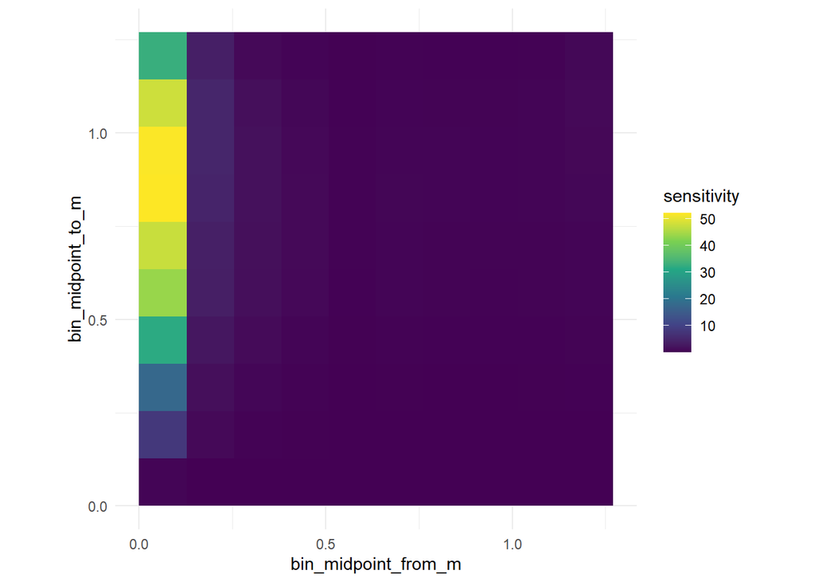

```r
sens_elas_plot_half.df =
  expand.grid(size_to = size_metadata_small$bin_id,
              size_from = size_metadata_small$bin_id) %>%
  left_join(size_metadata_small %>%
              select(size_to = bin_id,
                     bin_midpoint_to_m = bin_midpoint)) %>%
  left_join(size_metadata_small %>%
              select(size_from = bin_id,
                     bin_midpoint_from_m = bin_midpoint)) %>%
  expand(nesting(size_to, size_from, bin_midpoint_to_m, bin_midpoint_from_m),
         plot = 1:nrow(plots.pila)) %>%

  arrange(plot, size_to, size_from)

sens_elas_plot_half.df$sensitivity =

  sapply(X = 1:nrow(plots.pila),
         FUN = function(plot){

           sapply(X = 1:nrow(size_metadata_small),
                  FUN = function(size_to){

                    sapply(X = 1:nrow(size_metadata_small),
                           FUN = function(size_from){

                             sens_plot_half[size_to, size_from, plot]

                           })

                  })

         }) %>%
  as.vector()


sens_elas_plot_half.df %>%
  group_by(size_to, size_from, bin_midpoint_to_m, bin_midpoint_from_m) %>%
  summarise(sensitivity = median(sensitivity, na.rm = TRUE)) %>%
  ungroup() %>%
  ggplot(aes(x = bin_midpoint_from_m,
           y = bin_midpoint_to_m,
           fill = sensitivity))+
  geom_tile()+
  coord_fixed()+
  theme_minimal()+
  scale_fill_viridis_c()
```

```r
sens_elas_plot_half.df$elasticity =

  sapply(X = 1:nrow(plots.pila),
         FUN = function(plot){

           sapply(X = 1:nrow(size_metadata_small),
                  FUN = function(size_to){

                    sapply(X = 1:nrow(size_metadata_small),
                           FUN = function(size_from){

                             elas_plot_half[size_to, size_from, plot]

                           })

                  })

         }) %>%
  as.vector()
```

Again getting elasticity values outside the range 0-1:

```r
summary(sens_elas_plot_half.df)
```

```
##     size_to       size_from    bin_midpoint_to_m bin_midpoint_from_m
##  Min.   : 1.0   Min.   : 1.0   Min.   :0.0635    Min.   :0.0635
##  1st Qu.: 3.0   1st Qu.: 3.0   1st Qu.:0.3175    1st Qu.:0.3175
##  Median : 5.5   Median : 5.5   Median :0.6350    Median :0.6350
##  Mean   : 5.5   Mean   : 5.5   Mean   :0.6350    Mean   :0.6350
##  3rd Qu.: 8.0   3rd Qu.: 8.0   3rd Qu.:0.9525    3rd Qu.:0.9525
##  Max.   :10.0   Max.   :10.0   Max.   :1.2065    Max.   :1.2065
##       plot         sensitivity          elasticity
##  Min.   :   1.0   Min.   :    0.000   Min.   :0.000000
##  1st Qu.: 276.0   1st Qu.:    0.004   1st Qu.:0.000000
##  Median : 551.5   Median :    0.277   Median :0.000000
##  Mean   : 551.5   Mean   :    8.451   Mean   :0.078740
##  3rd Qu.: 827.0   3rd Qu.:    1.067   3rd Qu.:0.000216
##  Max.   :1102.0   Max.   :14001.879   Max.   :7.873982
```

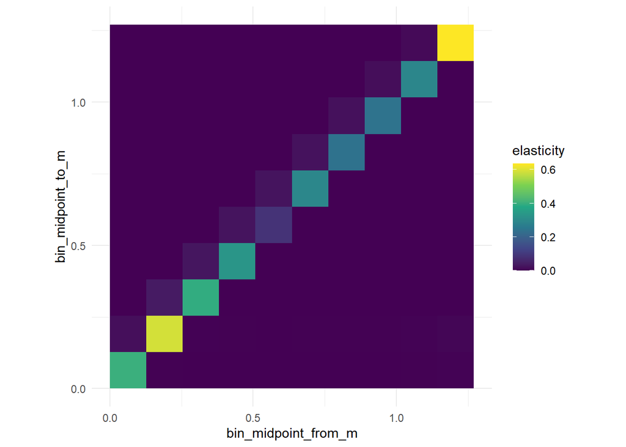

```r
sens_elas_plot_half.df %>%
  group_by(size_to, size_from, bin_midpoint_to_m, bin_midpoint_from_m) %>%
  summarise(sensitivity = median(sensitivity, na.rm = TRUE),
            elasticity = median(elasticity, na.rm = TRUE)) %>%
  ungroup() %>%
  ggplot(aes(x = bin_midpoint_from_m,
             y = bin_midpoint_to_m,
             fill = elasticity))+
  geom_tile()+
  coord_fixed()+
  theme_minimal()+
  scale_fill_viridis_c()
```

Truncating the size helps a lot, but doesn’t completely resolve the wonky results. I’m still getting negative reproductive values, elasticity values greater than 1 (is this a problem?), and the jitter caused by the varying class sizes.

# Hypothetical plots, limited size classes

## Build transition matrices

```r
A_hypotheticals =
  array(dim = c(nrow(size_metadata_small), # sizeclass to
                nrow(size_metadata_small), # sizeclass from
                nrow(hypothetical_plots), # plots
                nrow(posterior)), # posterior draws
        dimnames = list('class_to' = 1:nrow(size_metadata_small),
                        'class_from' = 1:nrow(size_metadata_small),
                        'plot' = 1:nrow(hypothetical_plots),
                        'draw' = 1:nrow(posterior)),
        data =
          sapply(X = 1:nrow(posterior),
                 FUN = function(draw){

                   # get beta_s for the current draw
                   beta_s =
                     posterior %>%
                     select(contains('beta_s')) %>%
                     slice(draw) %>%
                     as.data.frame() %>%
                     as.numeric()

                   beta_g =
                     posterior %>%
                     select(contains('beta_g')) %>%
                     slice(draw) %>%
                     as.data.frame() %>%
                     as.numeric()

                   beta_f =
                     posterior %>%
                     select(contains('beta_f')) %>%
                     slice(draw) %>%
                     as.data.frame() %>%
                     as.numeric()

                   sigmaEpsilon_g =
                     posterior %>%
                     slice(draw) %>%
                     pull(sigmaEpsilon_g) %>%
                     as.numeric()

                   sapply(X = 1:nrow(hypothetical_plots),
                          FUN = function(plot){

                            # construct explanatory variable matrix for survival
                            # for the current plot
                            X =
                              hypothetical_plots %>%
                              slice(plot) %>%
                              expand(nesting(intercept, fire, wpbr, ba_scaled,
                                             cwd_dep90_scaled,cwd_mean_scaled),
                                     dbh = size_metadata_small$dbh_m.mean) %>%
                              mutate(dbh_fire = dbh*fire,
                                     dbh_wpbr = dbh*wpbr,
                                     dbh_ba = dbh*ba_scaled,
                                     dbh_cwd_dep90 = dbh*cwd_dep90_scaled,
                                     dbh_cwd_mean = dbh*cwd_mean_scaled) %>%
                              select(intercept, dbh, fire, wpbr, ba_scaled,
                                     cwd_dep90_scaled, cwd_mean_scaled,
                                     dbh_fire, dbh_wpbr, dbh_ba,
                                     dbh_cwd_dep90, dbh_cwd_mean) %>%
                              as.matrix()

                            # calculate size_from length vector of survival
                            # probabilities on this plot with this parameter draw
                            p = boot::inv.logit(as.numeric(X %*% beta_s))

                            mu = as.numeric(X %*% beta_g)

                            f = exp(as.numeric(X %*% beta_f))

                            sapply(X = 1:nrow(size_metadata_small),
                                   FUN = function(class_from){

                                     g =
                                       ((pnorm(size_metadata_small$bin_upper,
                                               mu[class_from],
                                               sigmaEpsilon_g) -
                                           pnorm(size_metadata_small$bin_lower,
                                                 mu[class_from],
                                                 sigmaEpsilon_g))/
                                          (1-pnorm(0,
                                                mu[class_from],
                                                sigmaEpsilon_g)))

                                     sapply(X = 1:nrow(size_metadata_small),
                                            FUN = function(class_to){

                                              transition_prob =
                                                # survival of each from class
                                                (p[class_from] *
                                                # prob of growth from to
                                                g[class_to]) +
                                                # number of new recruits
                                                (f[class_from] *
                                                 size_metadata_small$r[class_to])
                                              return(transition_prob)

                                              # for testing
                                              #paste0('d:',draw,'|s:',plot,
                                              #  '|f:',class_from,'|t:',class_to)
                                            })
                                   })
                            })
                 }))


saveRDS(A_hypotheticals,
        here::here('02-data',
                   '03-results',
                   'real_fits',
                   'hypothetical_As.rds'))
```

```r
#### hypothetical transition matrices ##########################################
A_hypotheticals =
  readRDS(here::here('02-data',
                     '03-results',
                     'real_fits',
                     'hypothetical_As.rds'))
```

## Asymptotic population growth rate

```r
#### hypothetical lambda #######################################################

hypothetical_lambdas.matrix =
  matrix(nrow = nrow(hypothetical_plots),
         ncol = 4000,
         data =
           sapply(X = 1:nrow(hypothetical_plots),
                  FUN = function(plot){
                    sapply(X = 1:4000,
                           FUN = function(draw){
                             max(Re(eigen(A_hypotheticals[,,plot,draw])$values))
                           })
                  }))

hypothetical_lambdas =
  hypothetical_plots %>%
  expand(nesting(subp_id, name, intercept, fire, wpbr, ba_scaled,
                 cwd_dep90_scaled, cwd_mean_scaled),
         data.frame(draw = 1:4000))


hypothetical_lambdas$lambda =
  sapply(X = 1:nrow(hypothetical_plots),
         FUN = function(plot){
           sapply(X = 1:4000,
                  FUN = function(draw){
                    # paste0('s:',plot,'d:',draw) for testing
                    max(as.numeric(Re(eigen(A_hypotheticals[,,plot,draw])$values)))
                  })
         }) %>%
  as.numeric()


pretty_names =
  hypothetical_plots$name
names(pretty_names) = hypothetical_plots$subp_id

head(hypothetical_lambdas)
```

```
## # A tibble: 6 x 10
##   subp_id name        intercept fire  wpbr  ba_scaled cwd_dep90_scaled cwd_mean_scaled
##     <int> <chr>           <dbl> <lgl> <lgl>     <dbl>            <dbl>           <dbl>
## 1       1 Undisturbed         1 FALSE FALSE         0                0               0
## 2       1 Undisturbed         1 FALSE FALSE         0                0               0
## 3       1 Undisturbed         1 FALSE FALSE         0                0               0
## 4       1 Undisturbed         1 FALSE FALSE         0                0               0
## 5       1 Undisturbed         1 FALSE FALSE         0                0               0
## 6       1 Undisturbed         1 FALSE FALSE         0                0               0
## # ... with 2 more variables: draw <int>, lambda <dbl>
```

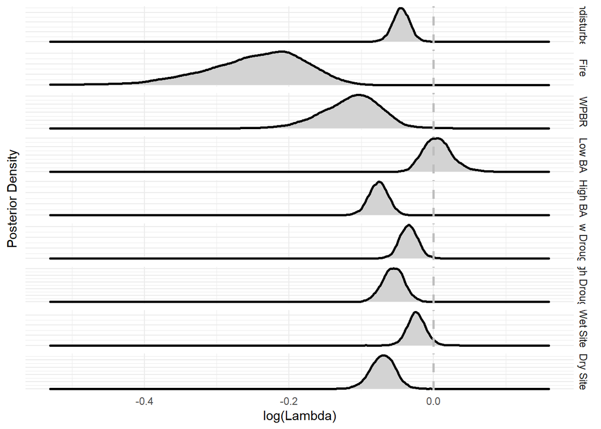

```r
ggplot(data =
           hypothetical_lambdas,
         aes(x = log(lambda)))+
  geom_density(lwd = 1, fill = 'lightgrey')+
  geom_vline(xintercept = 0, color = 'grey', lty = 2, lwd = 1)+
  theme_minimal()+
  facet_grid(subp_id~., scales = 'free_y',
             labeller = labeller(subp_id = pretty_names))+
  #scale_x_continuous(limits = c(0.5,3))+
  #coord_cartesian(xlim = c(0.9, 1.5))+
  theme(axis.text.y = element_blank())+
  labs(x = 'log(Lambda)', y = 'Posterior Density')
```

## Stable size distribution

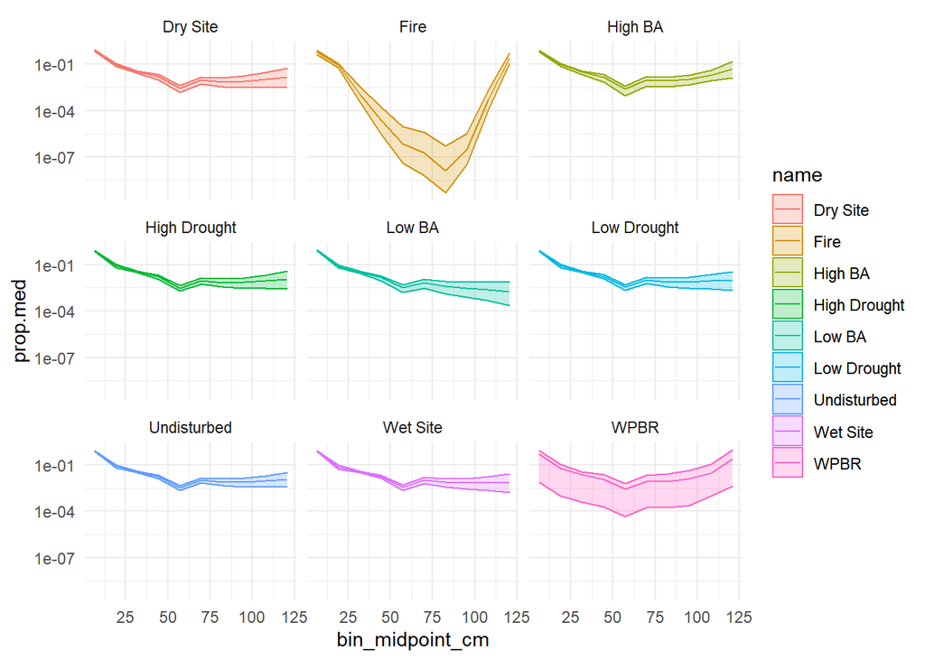

```r
#### hypothetical stable size distribution #####################################
hypothetical_ssd =
  array(dim = c(nrow(size_metadata_small),
                nrow(hypothetical_plots),
                4000),
        dimnames =
          list('sizeclass' = 1:nrow(size_metadata_small),
               'plot' = 1:nrow(hypothetical_plots),
               'draw' = 1:4000),
        data =
          sapply(X = 1:4000,
                 FUN = function(draw){
                   sapply(X = 1:nrow(hypothetical_plots),
                          FUN = function(plot){
                            A = A_hypotheticals[,,plot,draw]
                            w.eigen = Re(eigen(A)$vectors[,1])
                            ssd = w.eigen / sum(w.eigen)
                            return(ssd)
                          })
                 }))


hypothetical_ssd.df =
  hypothetical_plots %>%
  expand(nesting(intercept, fire, wpbr, ba_scaled, cwd_dep90_scaled,
                 cwd_mean_scaled, subp_id, name),
         sizeclass = 1:nrow(size_metadata_small),
         draw = 1:4000) %>%
  left_join(size_metadata_small %>%
              mutate(bin_midpoint_cm = bin_midpoint*100) %>%
              select(sizeclass = bin_id, bin_midpoint_cm)) %>%
  arrange(subp_id, sizeclass, draw)


hypothetical_ssd.df$class_proportion =

  as.numeric(
    sapply(X = 1:nrow(hypothetical_plots),
           FUN = function(plot){

             as.numeric(
               sapply(X = 1:nrow(size_metadata_small),
                      FUN = function(sizeclass){

                        return(hypothetical_ssd[sizeclass,plot,])
                      })
             )

           }))

# Fire makes the SSD really for the very rare bigger size classes, fewer
# mid-to-large trees and more superlarge
hypothetical_ssd.df %>%
  group_by(bin_midpoint_cm, sizeclass, name, subp_id) %>%
  summarise(prop.med = median(class_proportion),
            prop.05 = quantile(class_proportion, 0.05),
            prop.95 = quantile(class_proportion, 0.95)) %>%
  ungroup() %>%
  ggplot(aes(x = bin_midpoint_cm, color = name, fill = name))+
  #geom_point(aes(y = prop.med), size = 1)+
  geom_line(aes(y = prop.med))+
  geom_ribbon(aes(ymin = prop.05, ymax = prop.95), alpha = 0.25)+
  theme_minimal()+
  scale_y_log10()+
  facet_wrap(~name)
```

Looks reasonable.

## Reproductive value

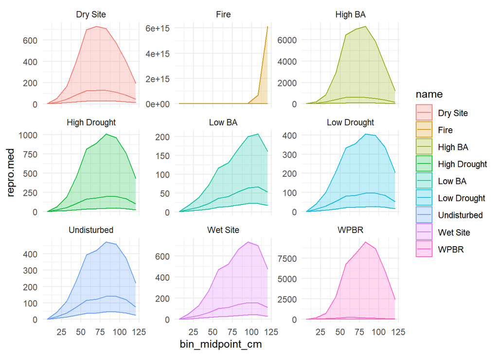

```r
#### hypothetical reproductive value ###########################################

hypothetical_repro =
  array(dim = c(nrow(size_metadata_small),
                nrow(hypothetical_plots),
                4000),
        dimnames =
          list('sizeclass' = 1:nrow(size_metadata_small),
               'plot' = 1:nrow(hypothetical_plots),
               'draw' = 1:4000),
        data =
          sapply(X = 1:4000,
                 FUN = function(draw){
                   sapply(X = 1:nrow(hypothetical_plots),
                          FUN = function(plot){
                            A = A_hypotheticals[,,plot,draw]
                            v.eigen = Re(eigen(t(A))$vectors[,1])
                            rv = v.eigen / v.eigen[1]
                            return(rv)
                          })
                 }))


hypothetical_repro.df =
  hypothetical_plots %>%
  expand(nesting(intercept, fire, wpbr, ba_scaled, cwd_dep90_scaled,
                 cwd_mean_scaled, subp_id, name),
         sizeclass = 1:nrow(size_metadata_small),
         draw = 1:4000) %>%
  left_join(size_metadata_small %>%
              mutate(bin_midpoint_cm = bin_midpoint*100) %>%
              select(sizeclass = bin_id, bin_midpoint_cm)) %>%
  arrange(subp_id, sizeclass, draw)

hypothetical_repro.df$repro =

  as.numeric(
    sapply(X = 1:nrow(hypothetical_plots),
           FUN = function(plot){

             as.numeric(
               sapply(X = 1:nrow(size_metadata_small),
                      FUN = function(sizeclass){

                        return(hypothetical_repro[sizeclass,plot,])
                      })
             )

           }))

# Again these reproductive values are wonky, esp for burned plots. Something
# about the transition matrix for burned plots is weird.
hypothetical_repro.df %>%
  group_by(bin_midpoint_cm, sizeclass, name, subp_id) %>%
  #filter(subp_id != 2) %>%
  summarise(repro.med = median(repro),
            repro.05 = quantile(repro, 0.05, na.rm = TRUE),
            repro.95 = quantile(repro, 0.95, na.rm = TRUE)) %>%
  ungroup() %>%
  ggplot(aes(x = bin_midpoint_cm, color = name, fill = name))+
  #geom_point(aes(y = prop.med), size = 1)+
  geom_line(aes(y = repro.med))+
  geom_ribbon(aes(ymin = repro.05, ymax = repro.95), alpha = 0.25)+
  theme_minimal()+
  facet_wrap(~name, scales = 'free_y')
```

So this looks more reasonable, I’m no longer getting the large negative reproductive values for the burned scenario 5th percentile.

Ok this kind of makes sense: under disturbances that really reduce the survival of small stems (WPBR and esp fire) the reproductive value of big stems relative to little ones is magnified, because so few little ones survive to become real contributors to reproduction; still think theres some numerical instability or smth causing the credible interval bounds for reproductive value to go wonky for fire, all the others look fine.

I am still getting a few large negative reproductive values:

```r
summary(hypothetical_repro.df)
```

```
##    intercept    fire            wpbr           ba_scaled  cwd_dep90_scaled
##  Min.   :1   Mode :logical   Mode :logical   Min.   :-1   Min.   :-1
##  1st Qu.:1   FALSE:320000    FALSE:320000    1st Qu.: 0   1st Qu.: 0
##  Median :1   TRUE :40000     TRUE :40000     Median : 0   Median : 0
##  Mean   :1                                   Mean   : 0   Mean   : 0
##  3rd Qu.:1                                   3rd Qu.: 0   3rd Qu.: 0
##  Max.   :1                                   Max.   : 1   Max.   : 1
##
##  cwd_mean_scaled    subp_id      name             sizeclass         draw
##  Min.   :-1      Min.   :1   Length:360000      Min.   : 1.0   Min.   :   1
##  1st Qu.: 0      1st Qu.:3   Class :character   1st Qu.: 3.0   1st Qu.:1001
##  Median : 0      Median :5   Mode  :character   Median : 5.5   Median :2000
##  Mean   : 0      Mean   :5                      Mean   : 5.5   Mean   :2000
##  3rd Qu.: 0      3rd Qu.:7                      3rd Qu.: 8.0   3rd Qu.:3000
##  Max.   : 1      Max.   :9                      Max.   :10.0   Max.   :4000
##
##  bin_midpoint_cm      repro
##  Min.   :  6.35   Min.   :  -Inf
##  1st Qu.: 31.75   1st Qu.: 25.39
##  Median : 63.50   Median : 81.40
##  Mean   : 63.50   Mean   :   NaN
##  3rd Qu.: 95.25   3rd Qu.:261.62
##  Max.   :120.65   Max.   :   Inf
##                   NA's   :26
```

All of them are from the fire scenario:

```r
hypothetical_repro.df %>%
  filter(repro<0) %>%
  pull(name) %>%
  unique()
```

```
## [1] "Fire"
```

## Sensitivity and elasticity

```r
#### hypothetical sensitivity and elasticity ###################################

# sensitivity and elasticity
hypothetical_vdotw =
  matrix(nrow = nrow(hypothetical_plots),
         ncol = 4000,
         data =
           sapply(X = 1:nrow(hypothetical_plots),
                  FUN = function(plot){
                    sapply(X = 1:4000,
                           FUN = function(draw){
                             sum(hypothetical_ssd[,plot,draw] *
                                   hypothetical_repro[,plot,draw])*0.127
                           })
                  }))


hypothetical_sens =
  array(dim = list(nrow(size_metadata_small),
                   nrow(size_metadata_small),
                   nrow(hypothetical_plots),
                   4000),
        dimnames =
          list('size_to' = 1:nrow(size_metadata_small),
               'size_from' = 1:nrow(size_metadata_small),
               'plot' = 1:nrow(hypothetical_plots),
               'draw' = 1:4000),
        data =

          sapply(X = 1:4000,
                 FUN = function(draw){
                   sapply(X = 1:nrow(hypothetical_plots),
                          FUN = function(plot){
                            outer(hypothetical_repro[,plot,draw],
                                  hypothetical_ssd[,plot,draw])/
                              hypothetical_vdotw[plot,draw]
                          })
                 })
  )

hypothetical_elas =
  array(dim = list(nrow(size_metadata_small),
                   nrow(size_metadata_small),
                   nrow(hypothetical_plots),
                   4000),
        dimnames =
          list('size_to' = 1:nrow(size_metadata_small),
               'size_from' = 1:nrow(size_metadata_small),
               'plot' = 1:nrow(hypothetical_plots),
               'draw' = 1:4000),
        data =

          sapply(X = 1:4000,
                 FUN = function(draw){
                   sapply(X = 1:nrow(hypothetical_plots),
                          FUN = function(plot){

                            matrix(as.vector(hypothetical_sens[,,plot,draw])*
                                     as.vector(A_hypotheticals[,,plot,draw])/
                                     hypothetical_lambdas.matrix[plot,draw])


                          })
                 })
  )



hypothetical_sens_elas.df  =
  expand.grid(size_to = size_metadata_small$bin_id,
              size_from = size_metadata_small$bin_id) %>%
  left_join(size_metadata_small %>%
              select(size_to = bin_id,
                     bin_midpoint_to_m = bin_midpoint)) %>%
  left_join(size_metadata_small %>%
              select(size_from = bin_id,
                     bin_midpoint_from_m = bin_midpoint)) %>%
  expand(nesting(size_to, size_from, bin_midpoint_to_m, bin_midpoint_from_m),
         subp_id = 1:9,
         draw = 1:4000) %>%
  arrange(subp_id, size_to, size_from, draw)


hypothetical_sens_elas.df$sensitivity =
  sapply(X = 1:nrow(hypothetical_plots),
         FUN = function(plot){
           sapply(X = 1:nrow(size_metadata_small),
                  FUN = function(size_to){

                    sapply(X = 1:nrow(size_metadata_small),
                           FUN = function(size_from){
                             hypothetical_sens[size_to, size_from, plot,]
                           })
                  })
         }) %>%
  as.vector()


hypothetical_sens_elas.df$elasticity =
  sapply(X = 1:nrow(hypothetical_plots),
         FUN = function(plot){
           sapply(X = 1:nrow(size_metadata_small),
                  FUN = function(size_to){

                    sapply(X = 1:nrow(size_metadata_small),
                           FUN = function(size_from){
                             hypothetical_elas[size_to, size_from, plot,]
                           })
                  })
         }) %>%
  as.vector()
```

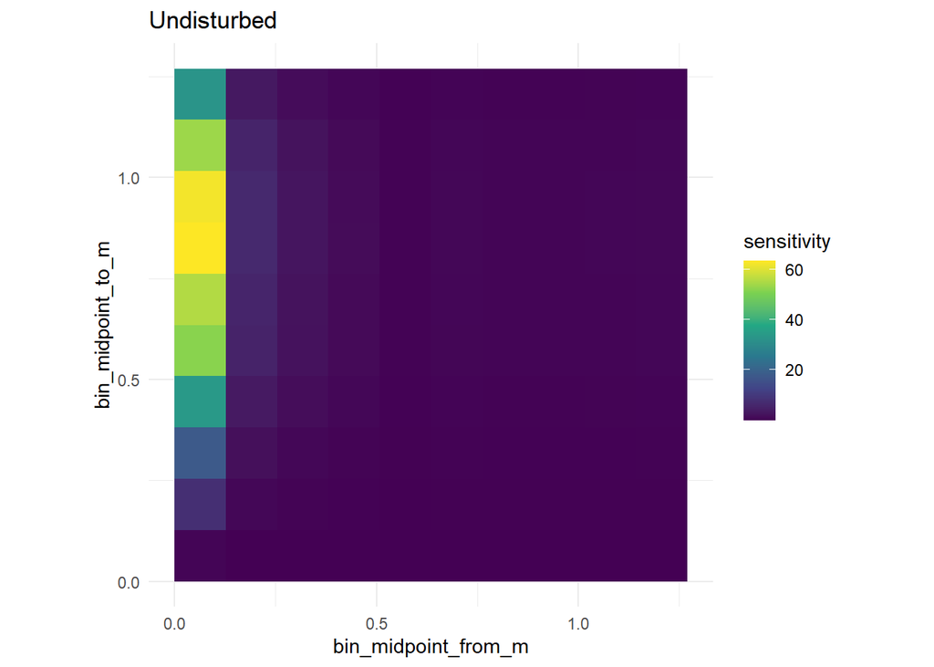

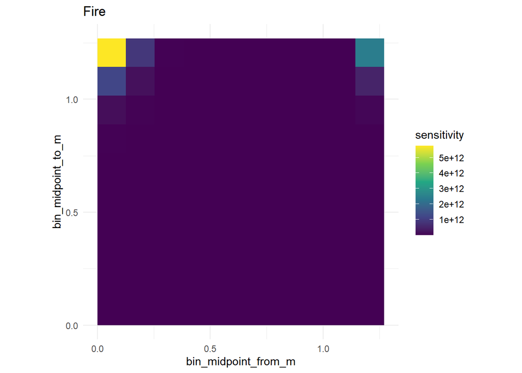

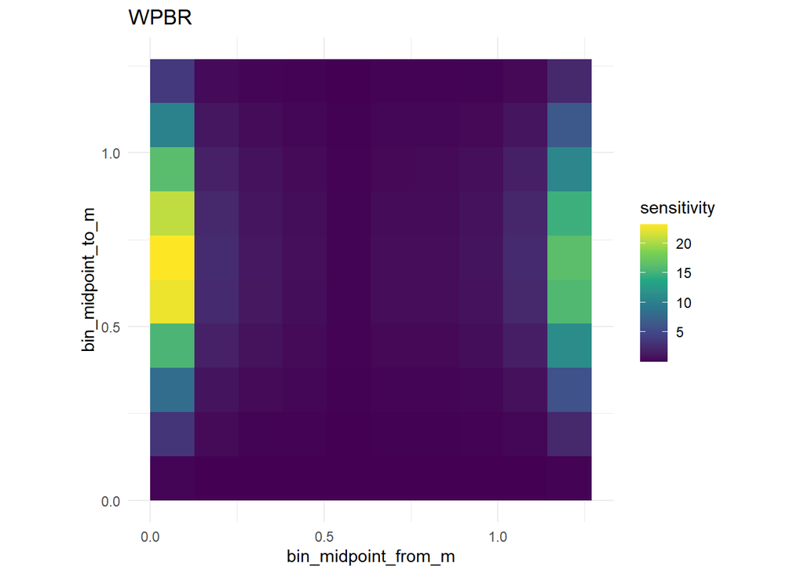

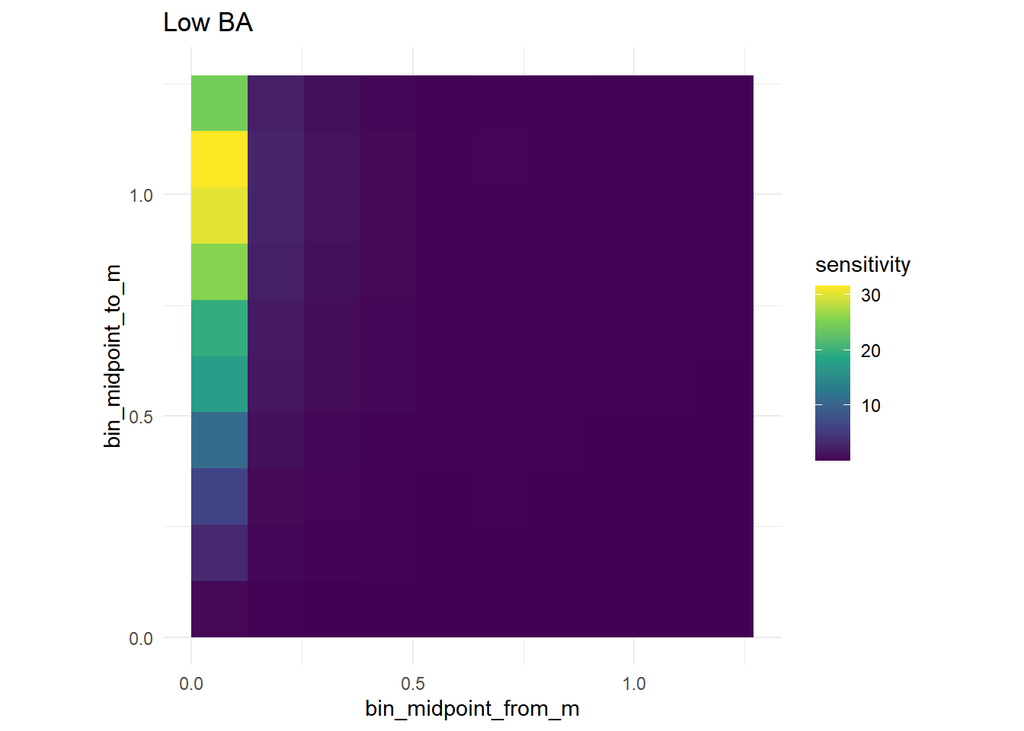

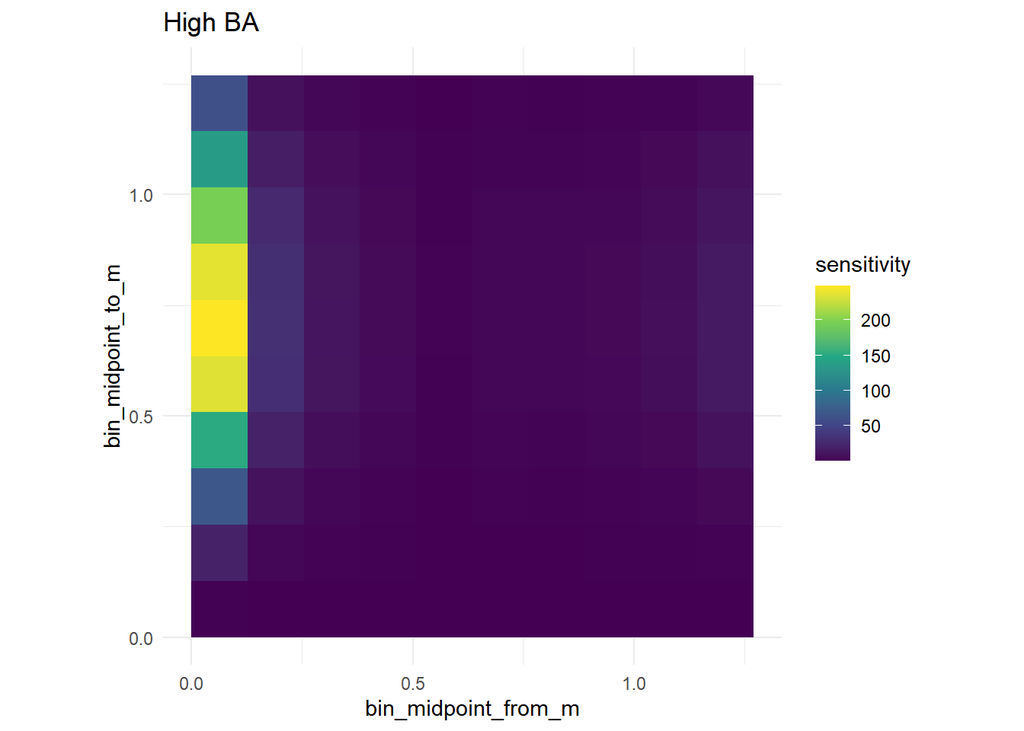

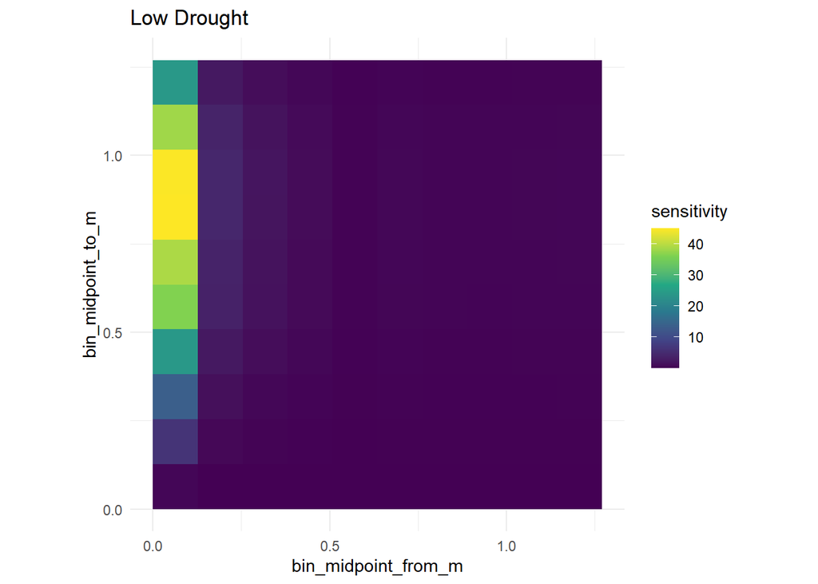

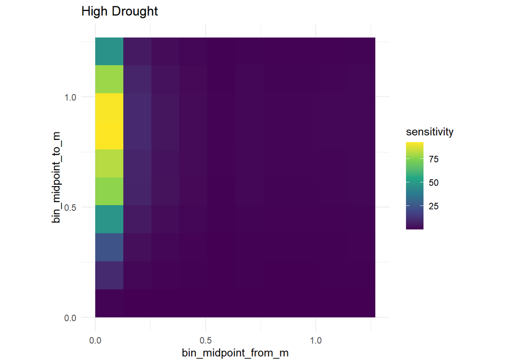

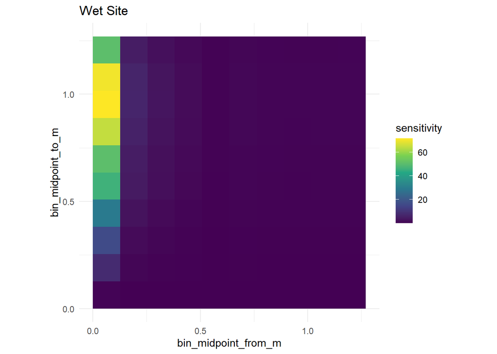

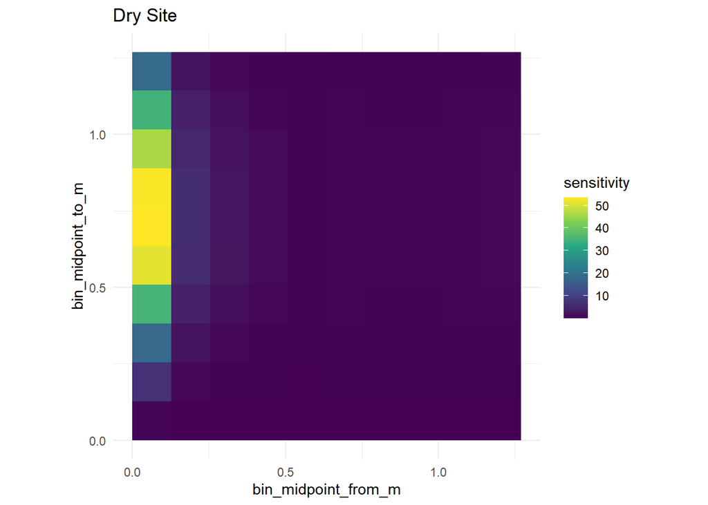

```r
sensitivity_plots =
  lapply(X = 1:9,
         FUN = function(s){

              hypothetical_sens_elas.df %>%
              group_by(size_to, size_from, bin_midpoint_to_m, bin_midpoint_from_m,
                       subp_id) %>%
              summarise(sensitivity = median(sensitivity, na.rm = TRUE),
                        elasticity = median(elasticity, na.rm = TRUE)) %>%
              ungroup() %>%
              left_join(hypothetical_plots %>%
                          select(subp_id, name)) %>%
              filter(subp_id==s) %>%
              ggplot(aes(x = bin_midpoint_from_m,
                         y = bin_midpoint_to_m,
                         fill = sensitivity))+
              geom_tile()+
              coord_fixed()+
              theme_minimal()+
              scale_fill_viridis_c()+
                labs(title = hypothetical_plots$name[s])
         })

sensitivity_plots
```

This looks much more sane than it did for the full size distribution.

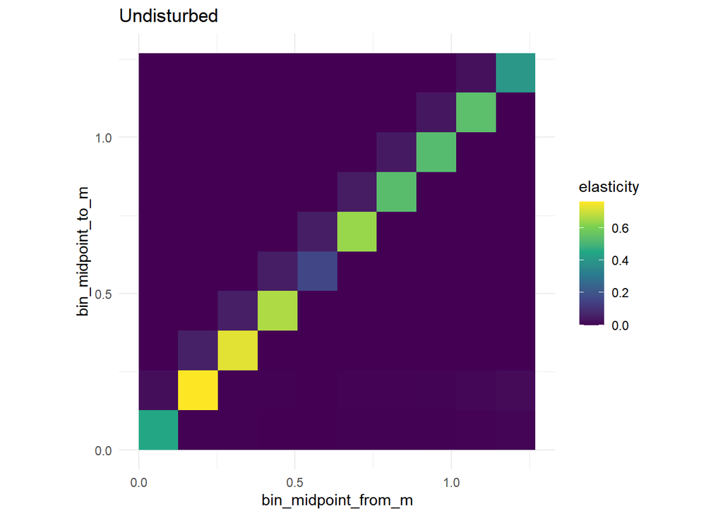

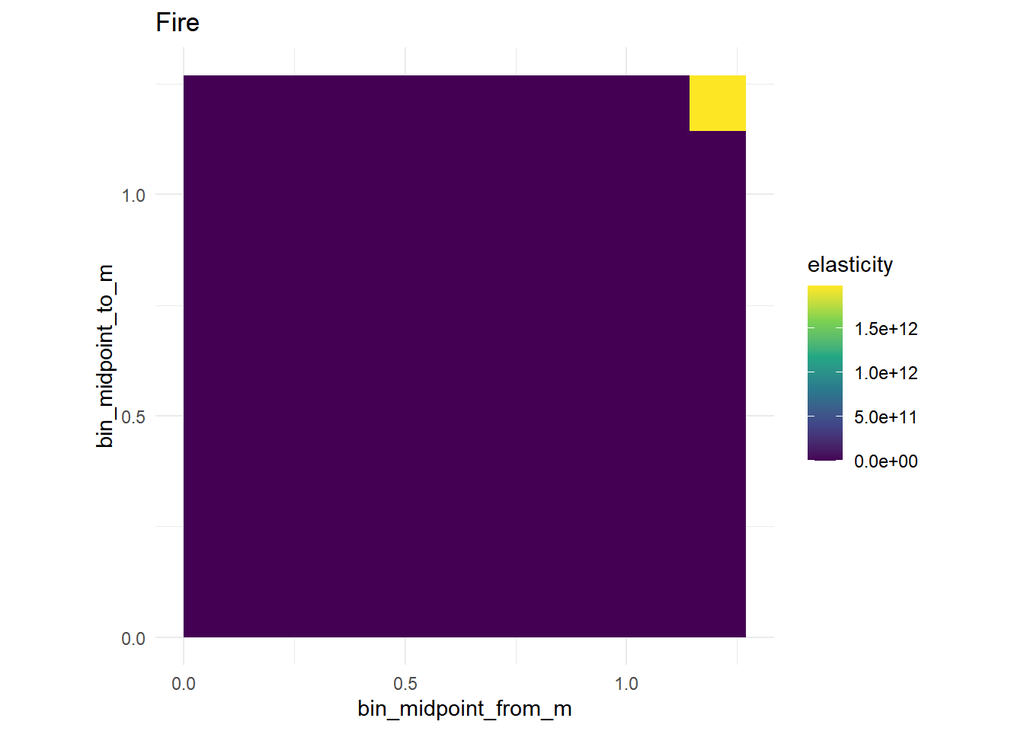

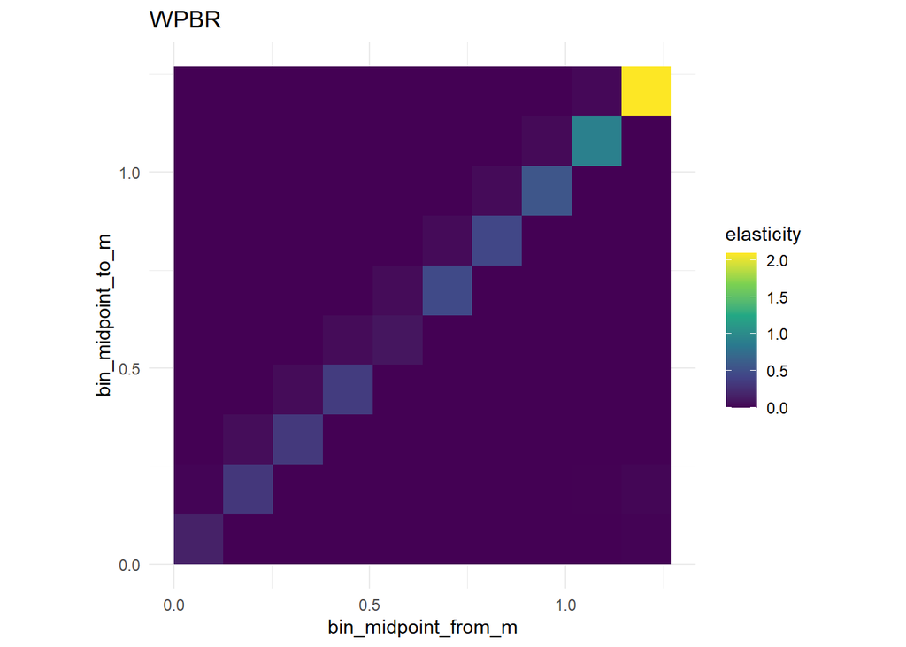

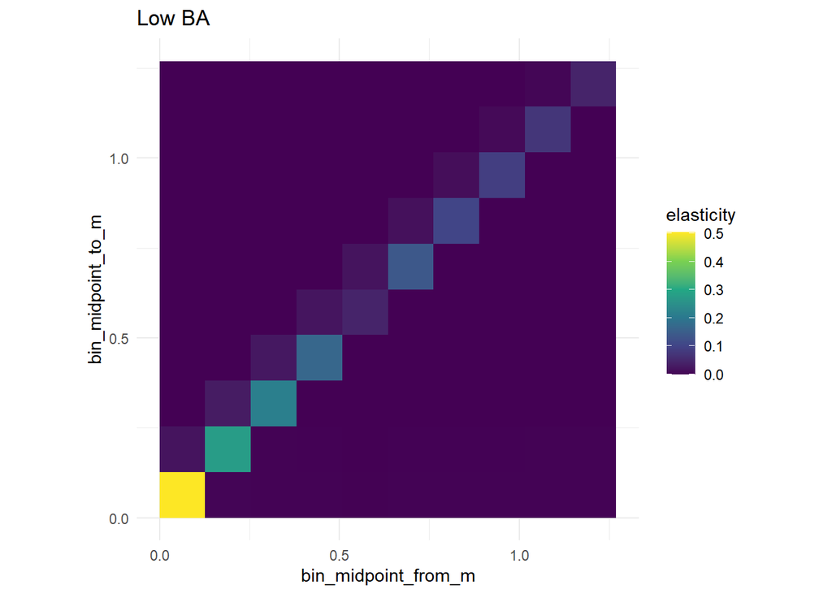

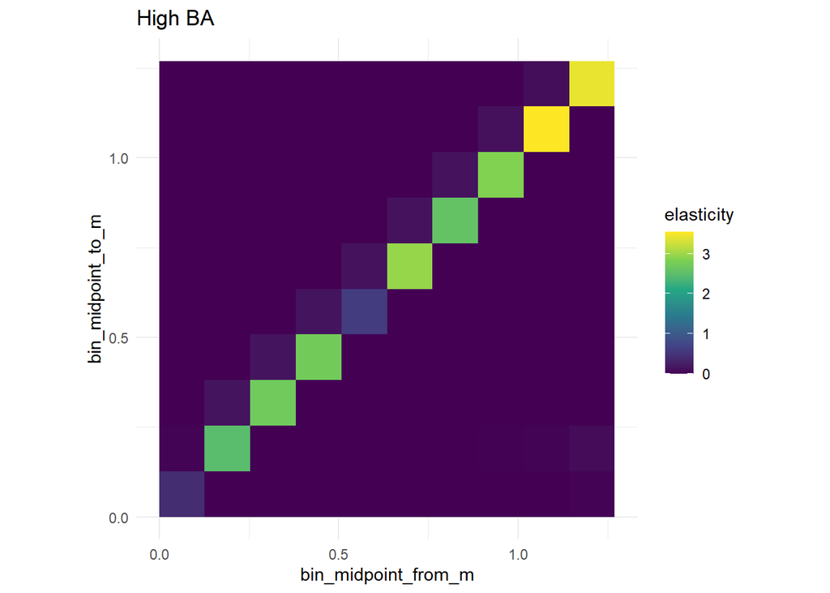

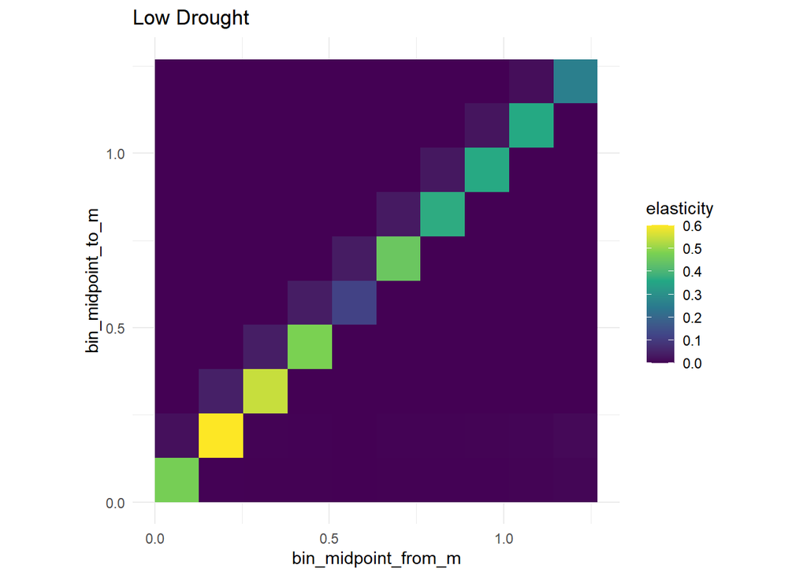

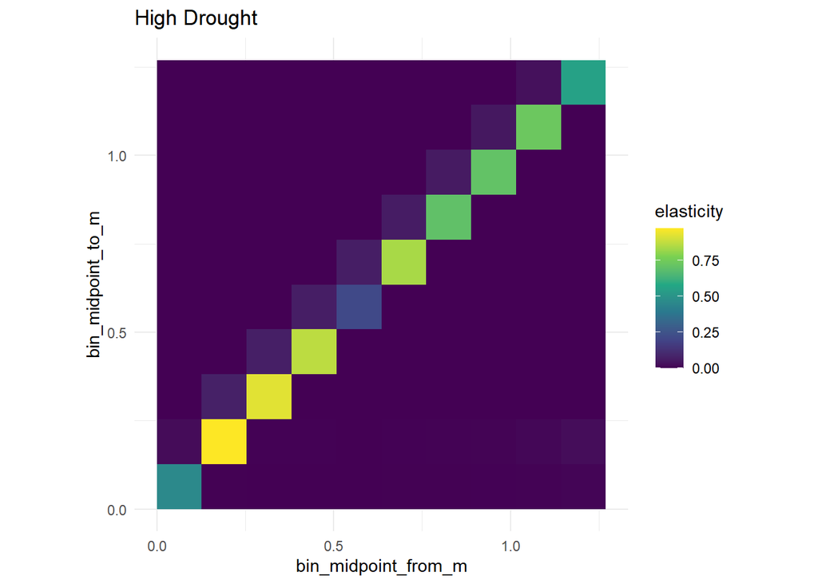

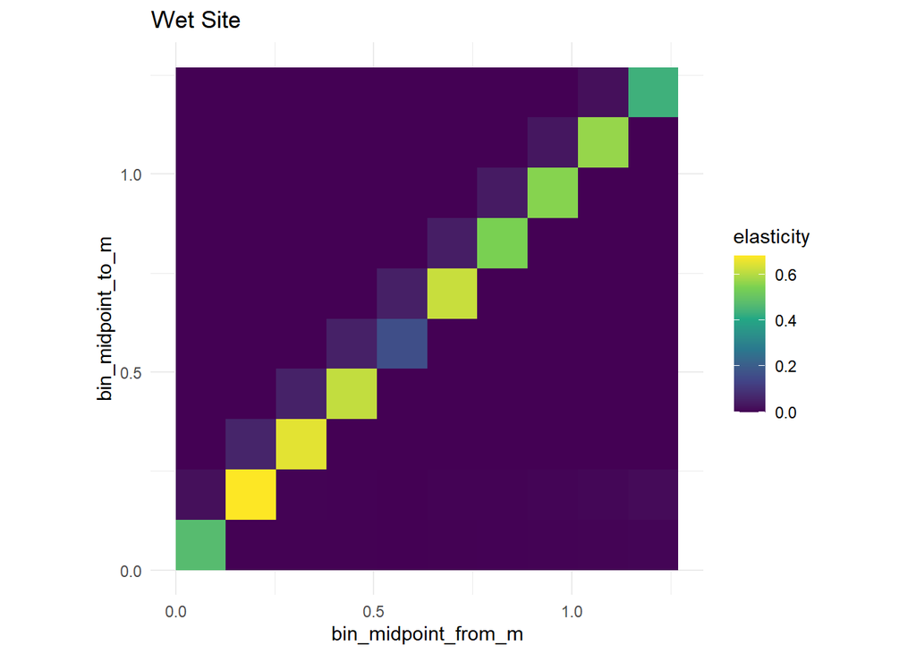

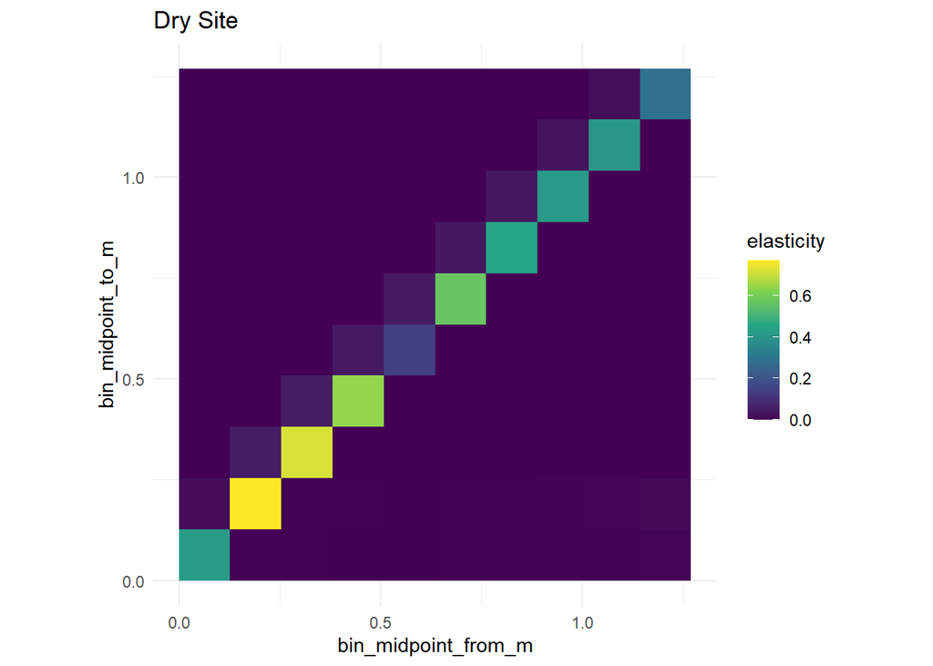

```r
elasticity_plots =
  lapply(X = 1:9,
         FUN = function(s){

              hypothetical_sens_elas.df %>%
              group_by(size_to, size_from, bin_midpoint_to_m, bin_midpoint_from_m,
                       subp_id) %>%
              summarise(sensitivity = median(sensitivity, na.rm = TRUE),
                        elasticity = median(elasticity, na.rm = TRUE)) %>%
              ungroup() %>%
              left_join(hypothetical_plots %>%
                          select(subp_id, name)) %>%
              filter(subp_id==s) %>%
              ggplot(aes(x = bin_midpoint_from_m,
                         y = bin_midpoint_to_m,
                         fill = elasticity))+
              geom_tile()+
              coord_fixed()+
              theme_minimal()+
              scale_fill_viridis_c()+
                labs(title = hypothetical_plots$name[s])
         })

elasticity_plots
```


Looking at the transition matrices, we get:

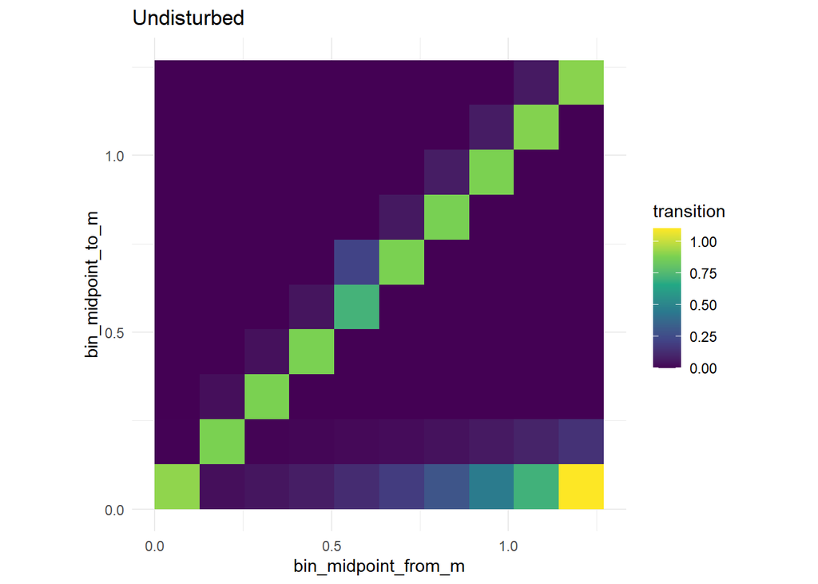

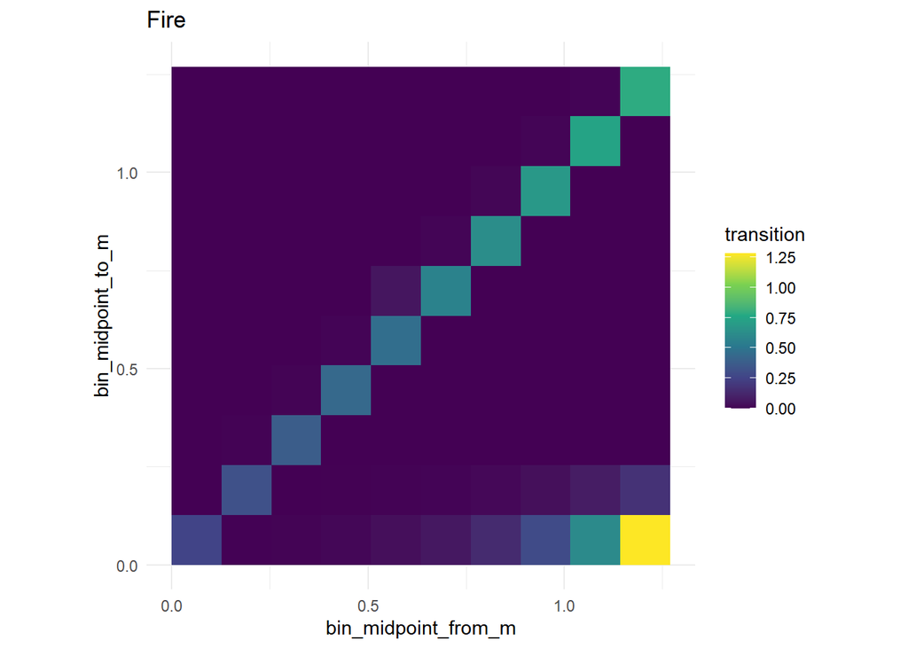

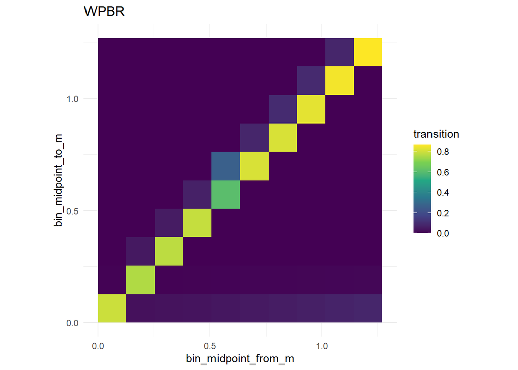

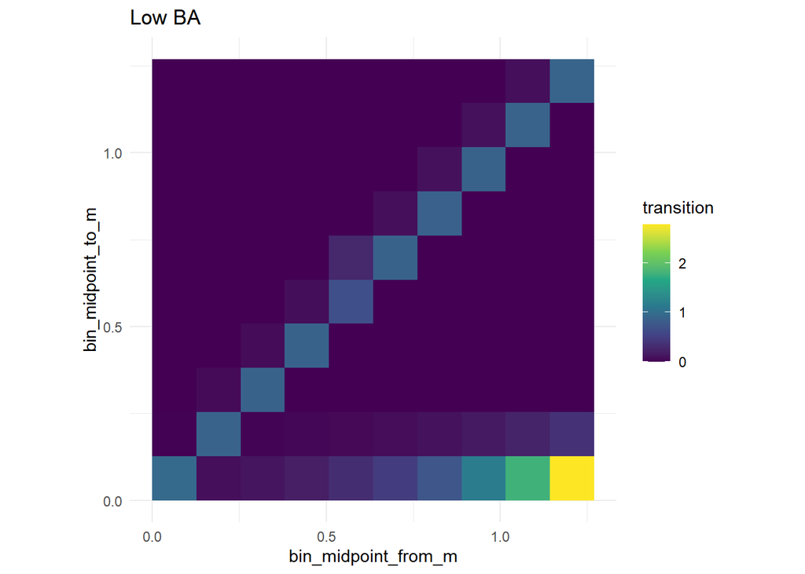

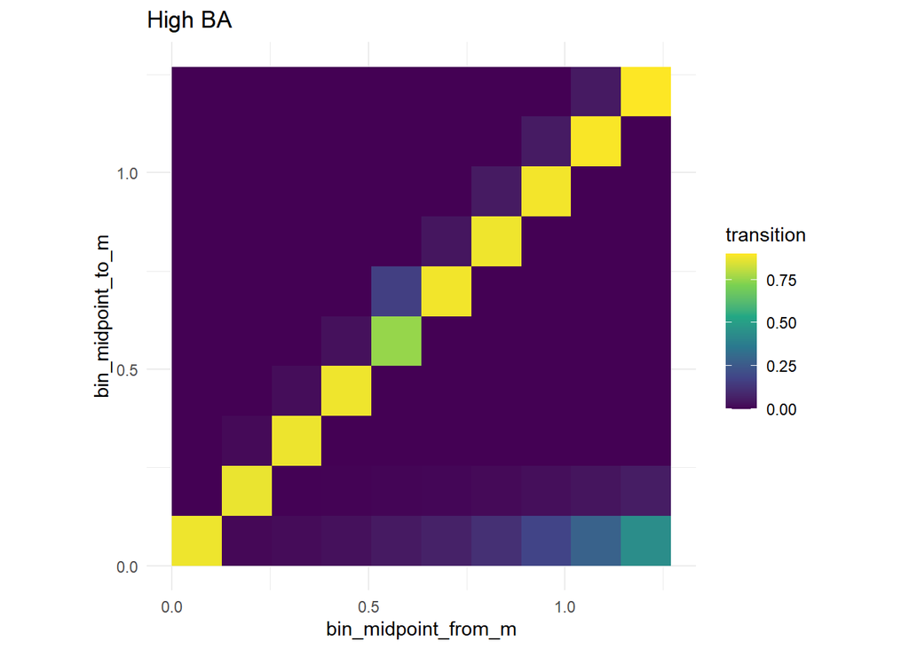

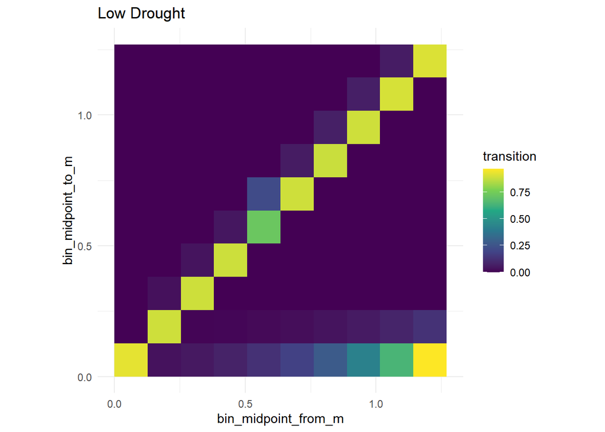

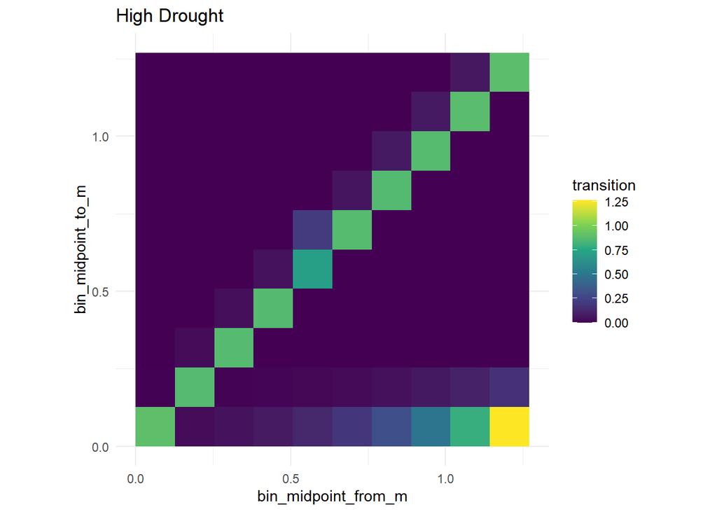

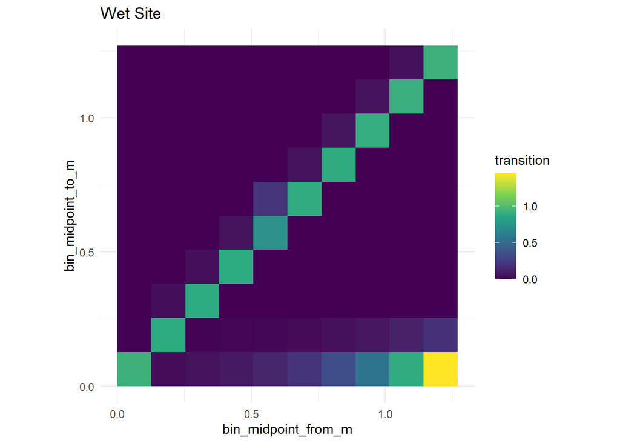

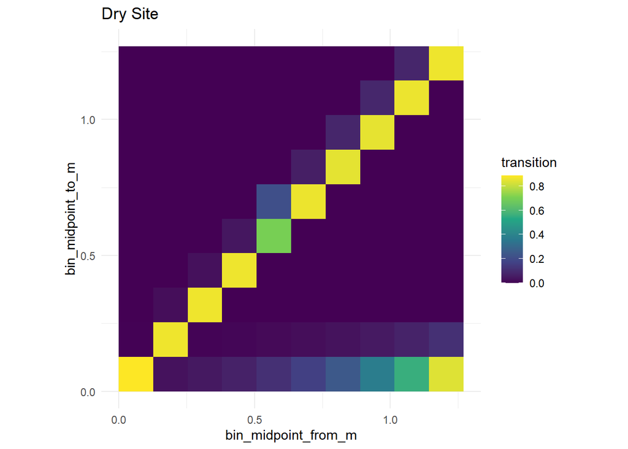

```r
hypothetical_sens_elas.df$transition =
    sapply(X = 1:nrow(hypothetical_plots),
         FUN = function(plot){
           sapply(X = 1:nrow(size_metadata_small),
                  FUN = function(size_to){

                    sapply(X = 1:nrow(size_metadata_small),
                           FUN = function(size_from){
                             A_hypotheticals[size_to, size_from, plot,]
                           })
                  })
         }) %>%
  as.vector()

transition_plots =
  lapply(X = 1:9,
         FUN = function(s){

              hypothetical_sens_elas.df %>%
              group_by(size_to, size_from, bin_midpoint_to_m, bin_midpoint_from_m,
                       subp_id) %>%
              summarise(sensitivity = median(sensitivity, na.rm = TRUE),
                        elasticity = median(elasticity, na.rm = TRUE),
                        transition = median(transition, na.rm = TRUE)) %>%
              ungroup() %>%
              left_join(hypothetical_plots %>%
                          select(subp_id, name)) %>%
              filter(subp_id==s) %>%
              ggplot(aes(x = bin_midpoint_from_m,
                         y = bin_midpoint_to_m,
                         fill = transition))+
              geom_tile()+
              coord_fixed()+
              theme_minimal()+
              scale_fill_viridis_c()+
                labs(title = hypothetical_plots$name[s])
         })

transition_plots
```

The median transition matrices look fine.

# Real plots, limited size range, midpoint rule

## Build transition matrices

```r
A_median_half_midpoint =
    array(dim = list(nrow(size_metadata_small),
                     nrow(size_metadata_small),
                     nrow(plots.pila)),
          dimnames = list('class_to' = 1:nrow(size_metadata_small),
                          'class_from' = 1:nrow(size_metadata_small),
                          'plot' = 1:nrow(plots.pila)),
          data =
            sapply(X = 1:nrow(plots.pila),
                   FUN = function(plot){

                     # construct explanatory variable matrix for vital rate
                     # functions for the current plot
                     X =
                       plots.pila %>%
                       slice(plot) %>%
                       expand(nesting(intercept, fire, wpbr, ba_scaled,
                                      cwd_dep90_scaled,cwd_mean_scaled),
                              dbh = size_metadata_small$bin_midpoint) %>%
                       mutate(dbh_fire = dbh*fire,
                              dbh_wpbr = dbh*wpbr,
                              dbh_ba = dbh*ba_scaled,
                              dbh_cwd_dep90 = dbh*cwd_dep90_scaled,
                              dbh_cwd_mean = dbh*cwd_mean_scaled) %>%
                       select(intercept, dbh, fire, wpbr, ba_scaled,
                              cwd_dep90_scaled, cwd_mean_scaled,
                              dbh_fire, dbh_wpbr, dbh_ba,
                              dbh_cwd_dep90, dbh_cwd_mean) %>%
                       as.matrix()

                     # calculate vector of survival probabilities for each
                     # size class on this plot with this parameter draw
                     p =
                       boot::inv.logit(as.numeric(X %*% beta_s) +
                                         ecoEffect_s[plots.pila$ecosub.i[plot]]+
                                         plotEffect_s[plots.pila$plot_id.i][plot])

                     # calculate vector of mean size at time 2 for each size
                     # class on this plot with this parameter draw
                     mu = as.numeric(X %*% beta_g)+
                       ecoEffect_g[plots.pila$ecosub.i[plot]]+
                       plotEffect_g[plots.pila$plot_id.i[plot]]

                     # calculate vector of fecundity for each size class on this
                     # plot with this parameter draw
                     f =
                       exp(as.numeric(X %*% beta_f)+
                             ecoEffect_f[plots.pila$ecosub.i[plot]]+
                             plotEffect_f[plots.pila$plot_id.i[plot]])

                     # loop over each "from" size class
                     sapply(X = 1:nrow(size_metadata_small),
                            FUN = function(class_from){

                              # growth kernel from this size class into
                              # each other size class, using the cumulative
                              # density function as recommended by Doak et al. 2021
                              g =
                                ((pnorm(size_metadata_small$bin_upper,
                                        mu[class_from],
                                        sigmaEpsilon_g) -
                                    pnorm(size_metadata_small$bin_lower,
                                          mu[class_from],
                                          sigmaEpsilon_g))/
                                   (1-pnorm(0,
                                            mu[class_from],
                                            sigmaEpsilon_g)))

                              # loop over every destination size class
                              sapply(X = 1:nrow(size_metadata_small),
                                     FUN = function(class_to){

                                       # for testing, just to make sure
                                       # I've constructed the array correctly
                                       #paste0('to:',class_to,',from:',class_from,
                                       #       ',plot:',plot)

                                       # calculate the transition kernel
                                       # between the current "from" class and
                                       # the current "to" class
                                       transition_kern =
                                         # survival of each from class
                                         (p[class_from] *
                                            # prob of growth from to
                                            g[class_to]) +
                                         # number of new recruits in this "to"
                                         # class is the fecundity of the "from"
                                         # class times the recruitment size
                                         # kernel for this "to" class
                                         (f[class_from] *
                                            size_metadata_small$r[class_to])
                                       return(transition_kern)

                                     })

                            })

                   }))

# save this so we don't have to rebuild it every time we knit
saveRDS(A_median_half_midpoint,
        here::here('02-data',
                   '03-results',
                   'real_fits',
                   'A_median_half_midpoint.rds'))
```

```r
A_median_half_midpoint = readRDS(here::here('02-data',
                                   '03-results',
                                   'real_fits',
                                   'A_median_half_midpoint.rds'))
```

Here’s the median transition matrix across all the plots:

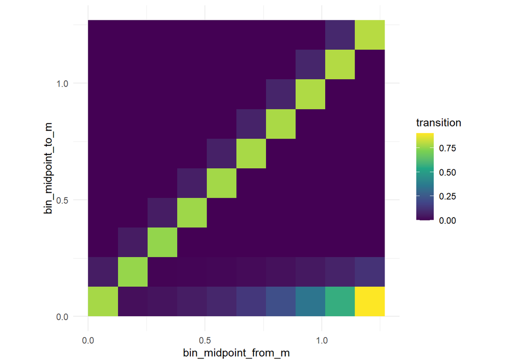

```r
sens_elas_plot_half_midpoint.df =
  expand.grid(size_to = size_metadata_small$bin_id,
              size_from = size_metadata_small$bin_id) %>%
  left_join(size_metadata_small %>%
              select(size_to = bin_id,
                     bin_midpoint_to_m = bin_midpoint)) %>%
  left_join(size_metadata_small %>%
              select(size_from = bin_id,
                     bin_midpoint_from_m = bin_midpoint)) %>%
  expand(nesting(size_to, size_from, bin_midpoint_to_m, bin_midpoint_from_m),
         plot = 1:nrow(plots.pila)) %>%

  arrange(plot, size_to, size_from)

sens_elas_plot_half_midpoint.df$transition =

  sapply(X = 1:nrow(plots.pila),
         FUN = function(plot){

           sapply(X = 1:nrow(size_metadata_small),
                  FUN = function(size_to){

                    sapply(X = 1:nrow(size_metadata_small),
                           FUN = function(size_from){

                             A_median_half_midpoint[size_to, size_from, plot]

                           })

                  })

         }) %>%
  as.vector()

sens_elas_plot_half_midpoint.df %>%
  group_by(size_to, size_from, bin_midpoint_to_m, bin_midpoint_from_m) %>%
  summarise(transition = median(transition)) %>%
  ungroup() %>%
  ggplot(aes(x = bin_midpoint_from_m,
             y = bin_midpoint_to_m,
             fill = transition))+
  geom_tile()+
  coord_fixed()+
  theme_minimal()+
  scale_fill_viridis_c()
```

Nice and smooth.

## Asymptotic population growth rate

```r
lambda_half_midpoint =
  sapply(X = 1:nrow(plots.pila),
         FUN = function(plot){
           A_plot = A_median_half_midpoint[,,plot]
           lambda_plot = max(as.numeric(Re(eigen(A_plot)$values)))
           return(lambda_plot)
         })
```

This is the equivalent to figure 7 in the paper, but with the size-restricted IPMs.

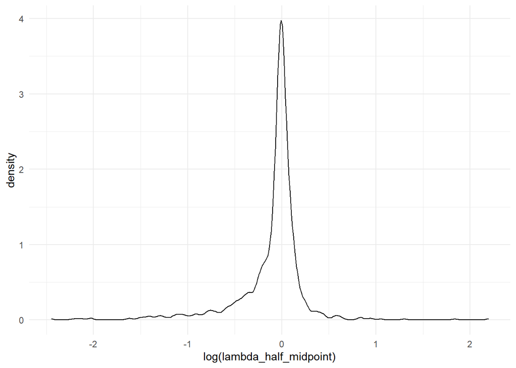

```r
ggplot(data.frame(lambda_half_midpoint),
       aes(x = log(lambda_half_midpoint)))+
  geom_density()+
  theme_minimal()
```

Here 60% of plots have lambda below 1:

```r
length(lambda_half_midpoint[lambda_half_midpoint < 1])/length(lambda_half_midpoint)
```

```
## [1] 0.600726
```

## Stable size distribution

```r
# stable size distribution
ssd_half_midpoint =
  matrix(nrow = nrow(size_metadata_small),
         ncol = nrow(plots.pila),
         byrow = FALSE,
         data =
           sapply(X = 1:nrow(plots.pila),
                  FUN = function(plot){
                    A.plot = A_median_half_midpoint[,,plot]
                    # from supplamentory materials for merow et al 2014
                    # "On using integral projection models..."
                    w.eigen = Re(eigen(A.plot)$vectors[,1])
                    ssd = w.eigen / sum(w.eigen)
                    return(ssd)
                  }))

ssd_half_midpoint.df =
  expand.grid('plot' = 1:nrow(plots.pila),
              'sizeclass' = 1:nrow(size_metadata_small)) %>%
  left_join(size_metadata_small %>%
              mutate(bin_midpoint_cm = bin_midpoint*100) %>%
              select(sizeclass = bin_id, bin_midpoint_cm))

ssd_half_midpoint.df$class_proportion =

  as.numeric(
    sapply(X = 1:nrow(size_metadata_small),
           FUN = function(sizeclass){

             return(ssd_half_midpoint[sizeclass,])

           })
  )
```

Stable size distribution is less skewed:

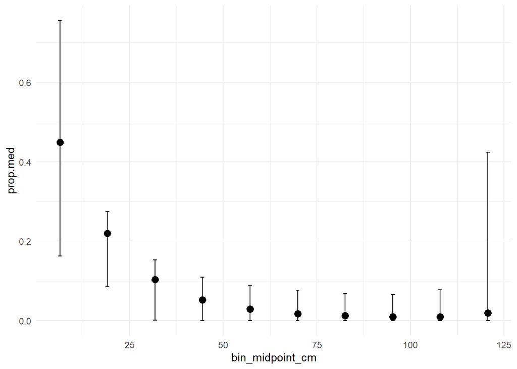

```r
# stable size distribution is inverse J not surprising
ssd_half_midpoint.df %>%
  group_by(bin_midpoint_cm, sizeclass) %>%
  summarise(prop.med = median(class_proportion),
            prop.05 = quantile(class_proportion, 0.05),
            prop.95 = quantile(class_proportion, 0.95)) %>%
  ungroup() %>%
  ggplot(aes(x = bin_midpoint_cm))+
  geom_point(aes(y = prop.med), size = 3)+
  geom_errorbar(aes(ymin = prop.05, ymax = prop.95),
                width = 1)+
  theme_minimal()
```

Still have trees accumulating in the largest size class. No problems with NAs or negative numbers here.

## Reproductive value

```r
plot_repro.half =
  matrix(nrow = nrow(size_metadata_small),
         ncol = nrow(plots.pila),
         byrow = FALSE,
         data =
           sapply(X = 1:nrow(plots.pila),
                  FUN = function(plot){
                    A.plot = A_median_half_midpoint[,,plot]
                    # from supplementary materials for merow et al 2014
                    # "On using integral projection models..."
                    v.eigen = Re(eigen(t(A.plot))$vectors[,1])
                    rv = v.eigen / v.eigen[1]
                    return(rv)
                  }))


plot_repro_half_midpoint.df =
  expand.grid('plot' = 1:nrow(plots.pila),
              'sizeclass' = 1:nrow(size_metadata_small)) %>%
  left_join(size_metadata_small %>%
              mutate(bin_midpoint_cm = bin_midpoint*100) %>%
              select(sizeclass = bin_id, bin_midpoint_cm))

plot_repro_half_midpoint.df$reproductive_value =

  as.numeric(
    sapply(X = 1:nrow(size_metadata_small),
           FUN = function(sizeclass){

             return(plot_repro.half[sizeclass,])

           })
  )
```

**STILL** have some large negative values.

```r
plot_repro_half_midpoint.df  %>% summary()
```

```
##       plot          sizeclass    bin_midpoint_cm  reproductive_value
##  Min.   :   1.0   Min.   : 1.0   Min.   :  6.35   Min.   :-8.004e+16
##  1st Qu.: 276.0   1st Qu.: 3.0   1st Qu.: 31.75   1st Qu.: 2.000e+00
##  Median : 551.5   Median : 5.5   Median : 63.50   Median : 7.000e+00
##  Mean   : 551.5   Mean   : 5.5   Mean   : 63.50   Mean   : 4.013e+14
##  3rd Qu.: 827.0   3rd Qu.: 8.0   3rd Qu.: 95.25   3rd Qu.: 3.300e+01
##  Max.   :1102.0   Max.   :10.0   Max.   :120.65   Max.   : 1.623e+18
```

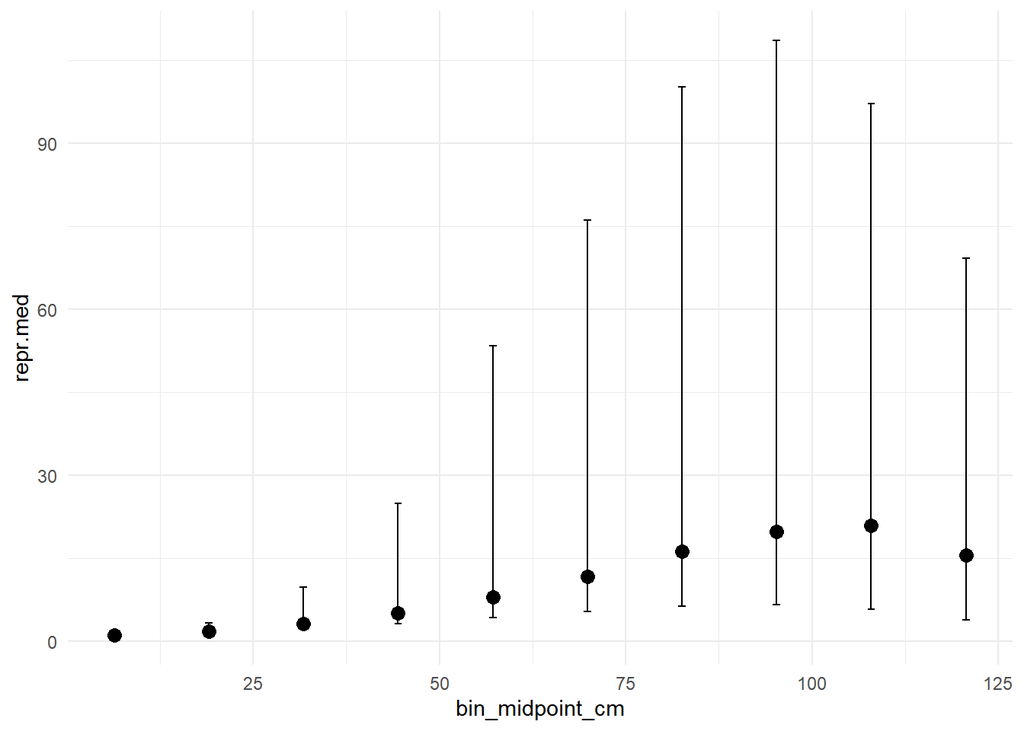

```r
plot_repro_half_midpoint.df %>%

  group_by(bin_midpoint_cm, sizeclass) %>%

  # there's a couple of NA plots for reproductive value, looks like cases
  # where numerical errors are resulting in a divide by zero when going from
  # v.eigen to reproductive value?
  summarise(repr.med = median(reproductive_value, na.rm = TRUE),

            # there's a couple of NAs in h
            repr.05 = quantile(reproductive_value, 0.25, na.rm = TRUE),
            repr.95 = quantile(reproductive_value, 0.75, na.rm = TRUE)) %>%
  ungroup() %>%
  ggplot(aes(x = bin_midpoint_cm))+
  geom_point(aes(y = repr.med), size = 3)+
  geom_errorbar(aes(ymin = repr.05, ymax = repr.95),
                width = 1)+
  theme_minimal()
```

Still have negative values in 75/11020 plot:sizeclasses, and still have reproductive value declining for the largest classes.

```r
nrow(plot_repro_half_midpoint.df %>% filter(reproductive_value<0))
```

```
## [1] 75
```

```r
plot_repro_half_midpoint.df %>%
  filter(reproductive_value<0)
```

```
##    plot sizeclass bin_midpoint_cm reproductive_value
## 1   188         2           19.05      -2.181534e+02
## 2   257         2           19.05      -9.233767e-01
## 3   412         2           19.05      -4.016927e+00
## 4   546         2           19.05      -3.878804e+00
## 5   575         2           19.05      -9.274194e-02
## 6   813         2           19.05      -1.779929e+00
## 7   846         2           19.05      -1.221116e+02
## 8   919         2           19.05      -6.432067e+00
## 9   976         2           19.05      -9.033088e+00
## 10 1101         2           19.05      -1.695000e+00
## 11  188         3           31.75      -6.075467e+04
## 12  575         3           31.75      -1.619251e+00
## 13  634         3           31.75      -1.606826e+02
## 14  846         3           31.75      -4.678375e+01
```

[output cut: 61 more lines]